# Part 2 — Citation graph: structural descriptions

## The two graphs

This part describes the citation graph and its communities twice. Both versions come from the annotated filter, which keeps the citations made by the 369 annotated papers. **Annotated** also keeps the seed paper’s own references. The seed, `lund2021`, is not annotated. It is the origin of the corpus and counts as one more citing paper in the edge list. **Annotated, seed filtered** drops the seed’s rows. Each table and plot below is computed on both graphs and shown in two tabs, Annotated first. “What the seed filter changes” compares the two directly.

| Metric | Annotated | Annotated, seed filtered |
| --- | --- | --- |
| Nodes | 12,697 | 12,696 |
| Edges | 21,737 | 21,368 |
| Directed | Yes | Yes |
| Density[^1] | 0.000134844 | 0.0001325758 |
| Weakly connected components[^2] | 1 | 3 |
| Largest weak component | 12,697 nodes (100% of graph) | 12,675 nodes (99.8% of graph) |
| Strongly connected components[^3] | 12,695 | 12,694 |
| Largest strong component | 2 nodes | 2 nodes |

## Degree and centrality

In-degree (times cited within the corpus) and out-degree (number of works cited) capture different roles. High in-degree identifies widely-cited works — the intellectual anchors of the field. High out-degree identifies works that are heavily engaged with the literature, drawing on many sources.

Betweenness centrality identifies works that sit on many shortest paths between other works — brokers between sub-literatures. Betweenness is expensive to compute on large graphs; both normalized and raw values are reported. Normalized divides by the theoretical maximum for a graph this size (roughly (n-1)(n-2) for a directed graph), so on a graph with over 12,697 nodes even a genuinely high-betweenness work normalizes to a very small fraction — small in absolute terms, not because the work is unimportant. Raw values, not rescaled, are more intuitively legible for comparing works directly against each other.

PageRank assigns authority based on incoming links weighted by the authority of the linking node — conceptually similar to being cited by works that are themselves widely cited. Hub and authority scores (HITS) are complementary: hubs point to many authorities; authorities are pointed to by many hubs.

Peripheral works — low degree, low centrality by every measure below — are not treated as noise in this project. A work cited only once may be exactly the interesting case (a niche, contested, or newly emerging reference) for a study of citational politics. No node is excluded from any measure in this section on the basis of low degree.

### Most cited (by in-degree)

**Annotated**

| name | title | year | generation | in_degree |
| --- | --- | --- | --- | --- |
| price2002 | The Viking way: religion and war in late Iron Age Scandinavia, Uppsala. Price, Neil In press: The archaeology of seiðr: circumpolar traditions in Viking pre-Christian religion | 2002 | F2 | 66 |
| svanberg2003 | Death rituals in south-east Scandinavia AD 800-1000: Decolonizing the Viking Age | 2003 | F2 | 31 |
| brink2008 | Slavery in the Viking Age | 2008 | F2 | 30 |
| skre2007 | Towns and Markets, Kings and Central Places in South-Western Scandinavia C. Ad 800-950 | 2007 | F2 | 29 |
| sindbaek2007networks | Networks and nodal points: the emergence of towns in early Viking Age Scandinavia | 2007 | F1 | 23 |
| price2008dying | Dying and the Dead | 2009 | F1 | 22 |
| zachrisson1998 | Gård, gräns och gravfält, sammanhang kring ädelmetalldepåer och runstenar från vikingatid och tidigmedeltid i uppland och gästrikland. stockholm studies in archaology 15 | 1998 | F2 | 21 |
| svanberg2003a | Decolonizing the Viking Age | 2003 | F2 | 21 |
| barrett2008what | What caused the Viking Age? | 2008 | F1 | 20 |
| hedeager2011 | Iron Age Myth and Materiality: An Archaeology of Scandinavia AD 400-1000. L and | 2011 | F2 | 20 |
| feveile2006 | ASR 1000 Ribelund II, in Det AEldste Ribe: Udgravninger på Nordsiden af Ribe Å 1984-2000, ed. C. Feveile. (Ribe Studier 1.2.) Aarhus: Jysk Arkaeologisk Selskab | 2006 | F2 | 20 |
| arbman1940 | Birka: Untersuchungen und Studien. 1. Die Gräber: Tafeln | 1940 | F2 | 19 |
| price2010passing | Passing into poetry: Viking-Age mortuary drama and the origins of Norse mythology | 2010 | F1 | 18 |
| price2011who | Who Was in Harold Bluetooth’s Army? Strontium Isotope Investigation of the Cemetery at the Viking Age Fortress at Trelleborg, Denmark | 2011 | F1 | 17 |
| andren2002 | Studier av nordisk förkristen ritual, Lund (Vägar till Midgård 2) | 2002 | F2 | 17 |
| sindbaek2005 | Ruter og rutinisering. Vikingetidens Fjernhandel i Nordeuropa, [summary in English: Routes and Routinization. Viking Age Long-Distance Trade in Northern Europe | 2005 | F2 | 17 |
| graslund1980 | Birka: Untersuchungen und Studien. iv, The Burial Customs: A Study of the Graves on Björkö. Stockholm: Almqvist & Wiksell international | 1980 | F2 | 17 |
| jorgensen2009pre | Pre-christian cult at aristocratic residences and setlement complexes in southern scandinavia in the 3 rd -10 th centuries ad | 2009 | F1 | 16 |
| sindbaek2011silver | Silver economies and social ties: Long-distance interaction, long-term investments -And why the Viking Age happened | 2011 | F1 | 16 |
| price2008 | Routledge, London. 2008b. Bodylore and the Archaeology of Embedded Religion: Dramatic License in the Funerals of the Vikings | 2008 | F2 | 16 |

**Annotated, seed filtered**

| name | title | year | generation | in_degree |
| --- | --- | --- | --- | --- |
| price2002 | The Viking way: religion and war in late Iron Age Scandinavia, Uppsala. Price, Neil In press: The archaeology of seiðr: circumpolar traditions in Viking pre-Christian religion | 2002 | F2 | 66 |
| svanberg2003 | Death rituals in south-east Scandinavia AD 800-1000: Decolonizing the Viking Age | 2003 | F2 | 31 |
| brink2008 | Slavery in the Viking Age | 2008 | F2 | 30 |
| skre2007 | Towns and Markets, Kings and Central Places in South-Western Scandinavia C. Ad 800-950 | 2007 | F2 | 29 |
| sindbaek2007networks | Networks and nodal points: the emergence of towns in early Viking Age Scandinavia | 2007 | F1 | 22 |
| price2008dying | Dying and the Dead | 2009 | F1 | 21 |
| zachrisson1998 | Gård, gräns och gravfält, sammanhang kring ädelmetalldepåer och runstenar från vikingatid och tidigmedeltid i uppland och gästrikland. stockholm studies in archaology 15 | 1998 | F2 | 21 |
| svanberg2003a | Decolonizing the Viking Age | 2003 | F2 | 21 |
| hedeager2011 | Iron Age Myth and Materiality: An Archaeology of Scandinavia AD 400-1000. L and | 2011 | F2 | 20 |
| feveile2006 | ASR 1000 Ribelund II, in Det AEldste Ribe: Udgravninger på Nordsiden af Ribe Å 1984-2000, ed. C. Feveile. (Ribe Studier 1.2.) Aarhus: Jysk Arkaeologisk Selskab | 2006 | F2 | 20 |
| barrett2008what | What caused the Viking Age? | 2008 | F1 | 19 |
| arbman1940 | Birka: Untersuchungen und Studien. 1. Die Gräber: Tafeln | 1940 | F2 | 19 |
| price2010passing | Passing into poetry: Viking-Age mortuary drama and the origins of Norse mythology | 2010 | F1 | 17 |
| andren2002 | Studier av nordisk förkristen ritual, Lund (Vägar till Midgård 2) | 2002 | F2 | 17 |
| sindbaek2005 | Ruter og rutinisering. Vikingetidens Fjernhandel i Nordeuropa, [summary in English: Routes and Routinization. Viking Age Long-Distance Trade in Northern Europe | 2005 | F2 | 17 |
| graslund1980 | Birka: Untersuchungen und Studien. iv, The Burial Customs: A Study of the Graves on Björkö. Stockholm: Almqvist & Wiksell international | 1980 | F2 | 17 |
| price2011who | Who Was in Harold Bluetooth’s Army? Strontium Isotope Investigation of the Cemetery at the Viking Age Fortress at Trelleborg, Denmark | 2011 | F1 | 16 |
| price2008 | Routledge, London. 2008b. Bodylore and the Archaeology of Embedded Religion: Dramatic License in the Funerals of the Vikings | 2008 | F2 | 16 |
| skre2008 | Dark Age Towns: The Kaupang Case. Reply to Przemysław Urbańczyk | 2008 | F2 | 16 |
| wamers1985 | Insularer Metallschmuck in Wikingerzeitlichen Gräbern Nordeuropas: Untersuchungen zur Skandinavischen Westexpansion. (Ofa-Bücher 56.) Neumünster | 1985 | F2 | 16 |

### Most citing (by out-degree)

**Annotated**

| name | title | year | generation | out_degree |
| --- | --- | --- | --- | --- |
| lund2021 | Crossing the Maelstrom: New Departures in Viking Archaeology | 2021 | P | 369 |
| anchukaitis2017last | Last millennium Northern Hemisphere summer temperatures from tree rings: Part II, spatially resolved reconstructions | 2017 | F1 | 225 |
| raffield2019playing | Playing Vikings: Militarism, hegemonic masculinities, and childhood enculturation in Viking Age Scandinavia | 2019 | F1 | 217 |
| milek2012roles | The roles of pit houses and gendered spaces on Viking-Age farmsteads in Iceland | 2012 | F1 | 174 |
| bill2020ship | The Ship Graves on Kormt – and Beyond | 2019 | F1 | 171 |
| barrett2010rounding | Rounding up the usual suspects: Causation and the Viking Age diaspora | 2010 | F1 | 170 |
| raffield2018polygyny | Polygyny, concubinage and the social lives of women in Viking Age Scandinavia | 2018 | F1 | 158 |
| knudson2012migration | Migration and Viking Dublin: Paleomobility and paleodiet through isotopic analyses | 2012 | F1 | 152 |
| hartman2017medieval | Medieval Iceland, Greenland, and the New Human Condition: A case study in integrated environmental humanities | 2017 | F1 | 151 |
| solli2011some | Some reflections on heritage and archaeology in the Anthropocene | 2011 | F1 | 147 |
| glorstad2012sign | Sign of the times? The transfer and transformation of Pennannular Brooches in Viking-Age Norway | 2012 | F1 | 145 |
| skre2019rulership | Rulership and Ruler’s Sites in 1st–10th-century Scandinavia | 2019 | F1 | 145 |
| gardela2018amazons | Amazons of the North? Armed females in Viking archaeology and medieval literature | 2018 | F1 | 145 |
| barrett2008what | What caused the Viking Age? | 2008 | F1 | 139 |
| keller2016northern | The northern frontier -North Atlantic farming during the Viking and Middle Ages | 2016 | F1 | 138 |
| fabech2013ritual | Ritual landscapes and sacral places in the first millennium AD in South Scandinavia | 2013 | F1 | 137 |
| lund2013fragments | Fragments of a conversion: handling bodies and objects in pagan and Christian Scandinavia AD 800-1100 | 2013 | F1 | 137 |
| oehrl2017documenting | Documenting and interpreting the picture stones of Gotland: Old problems and new approaches | 2017 | F1 | 131 |
| hardh2010viking | Viking Age Uppåkra | 2010 | F1 | 129 |
| andren2000reading | Re-Reading Embodied Texts: An Interpretation of Rune-Stones | 2000 | F1 | 126 |

**Annotated, seed filtered**

| name | title | year | generation | out_degree |
| --- | --- | --- | --- | --- |
| anchukaitis2017last | Last millennium Northern Hemisphere summer temperatures from tree rings: Part II, spatially resolved reconstructions | 2017 | F1 | 225 |
| raffield2019playing | Playing Vikings: Militarism, hegemonic masculinities, and childhood enculturation in Viking Age Scandinavia | 2019 | F1 | 217 |
| milek2012roles | The roles of pit houses and gendered spaces on Viking-Age farmsteads in Iceland | 2012 | F1 | 174 |
| bill2020ship | The Ship Graves on Kormt – and Beyond | 2019 | F1 | 171 |
| barrett2010rounding | Rounding up the usual suspects: Causation and the Viking Age diaspora | 2010 | F1 | 170 |
| raffield2018polygyny | Polygyny, concubinage and the social lives of women in Viking Age Scandinavia | 2018 | F1 | 158 |
| knudson2012migration | Migration and Viking Dublin: Paleomobility and paleodiet through isotopic analyses | 2012 | F1 | 152 |
| hartman2017medieval | Medieval Iceland, Greenland, and the New Human Condition: A case study in integrated environmental humanities | 2017 | F1 | 151 |
| solli2011some | Some reflections on heritage and archaeology in the Anthropocene | 2011 | F1 | 147 |
| glorstad2012sign | Sign of the times? The transfer and transformation of Pennannular Brooches in Viking-Age Norway | 2012 | F1 | 145 |
| skre2019rulership | Rulership and Ruler’s Sites in 1st–10th-century Scandinavia | 2019 | F1 | 145 |
| gardela2018amazons | Amazons of the North? Armed females in Viking archaeology and medieval literature | 2018 | F1 | 145 |
| barrett2008what | What caused the Viking Age? | 2008 | F1 | 139 |
| keller2016northern | The northern frontier -North Atlantic farming during the Viking and Middle Ages | 2016 | F1 | 138 |
| fabech2013ritual | Ritual landscapes and sacral places in the first millennium AD in South Scandinavia | 2013 | F1 | 137 |
| lund2013fragments | Fragments of a conversion: handling bodies and objects in pagan and Christian Scandinavia AD 800-1100 | 2013 | F1 | 137 |
| oehrl2017documenting | Documenting and interpreting the picture stones of Gotland: Old problems and new approaches | 2017 | F1 | 131 |
| hardh2010viking | Viking Age Uppåkra | 2010 | F1 | 129 |
| andren2000reading | Re-Reading Embodied Texts: An Interpretation of Rune-Stones | 2000 | F1 | 126 |
| jackson2018disequilibrium | Disequilibrium, adaptation, and the Norse settlement of Greenland | 2018 | F1 | 125 |

### Degree distribution

A power-law or scale-free degree distribution is characteristic of citation networks: most works are cited rarely, a small number are cited frequently, visible as a roughly straight-line decline on a log-log plot. The plot below tests whether this corpus follows that pattern.

**Annotated**

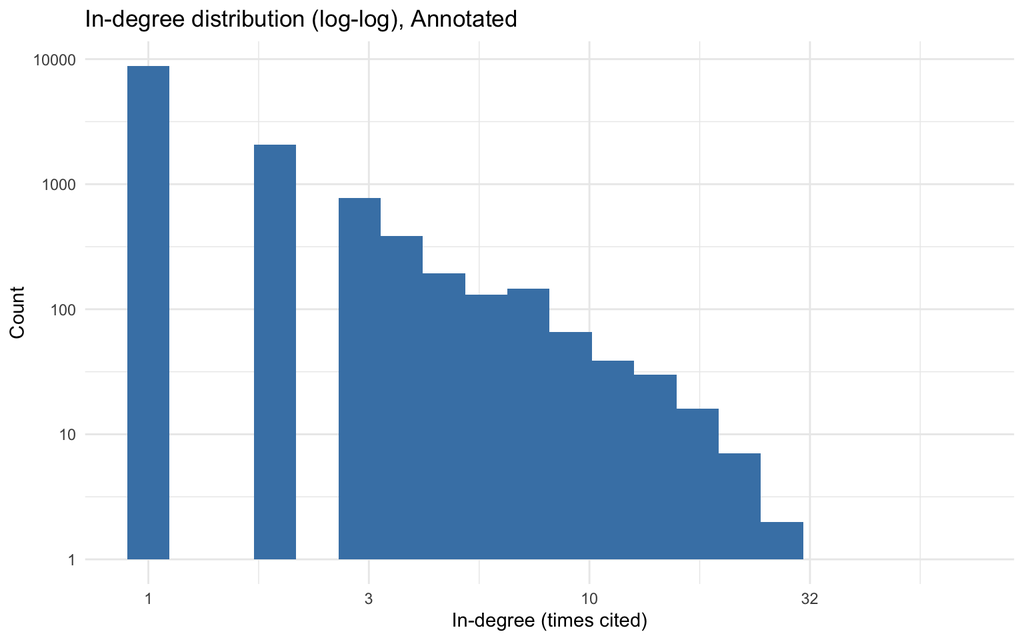

**Annotated, seed filtered**

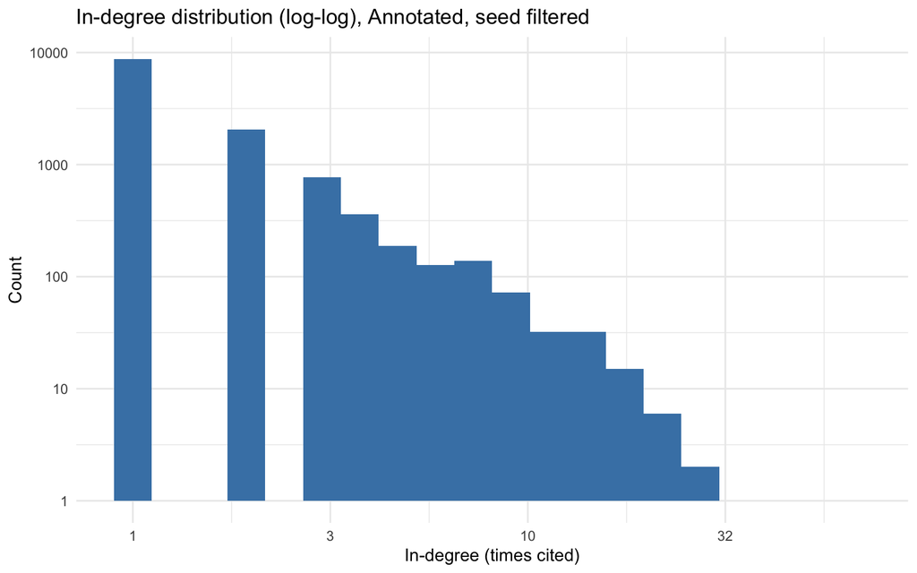

The bulk of the distribution follows a fairly straight decline on this log-log scale, consistent with the expected power-law pattern: most works are cited once or twice (86% of works with at least one citation in Annotated and 86% in Annotated, seed filtered), a much smaller number several times. In Annotated, 99% of works with at least one citation are cited eight times or fewer, and 99% in Annotated, seed filtered. The tail is real, not an artifact of a truncated plot axis: the maximum in-degree is 66 in Annotated and 66 in Annotated, seed filtered. A handful of works drive that high-citation tail, listed below rather than relied on to show clearly as bars on the histogram above, since bars this sparse are easy to miss regardless of binning.

### Most-cited works (the high end of the tail)

The most-cited works in each graph, driving the sparse, high-in-degree tail visible in the plots above:

**Annotated**

| name | title | year | in_degree |
| --- | --- | --- | --- |
| price2002 | The Viking way: religion and war in late Iron Age Scandinavia, Uppsala. Price, Neil In press: The archaeology of seiðr: circumpolar traditions in Viking pre-Christian religion | 2002 | 66 |
| svanberg2003 | Death rituals in south-east Scandinavia AD 800-1000: Decolonizing the Viking Age | 2003 | 31 |

**Annotated, seed filtered**

| name | title | year | in_degree |
| --- | --- | --- | --- |
| price2002 | The Viking way: religion and war in late Iron Age Scandinavia, Uppsala. Price, Neil In press: The archaeology of seiðr: circumpolar traditions in Viking pre-Christian religion | 2002 | 66 |
| svanberg2003 | Death rituals in south-east Scandinavia AD 800-1000: Decolonizing the Viking Age | 2003 | 31 |

### Top by betweenness centrality

Works with high betweenness mediate between otherwise disconnected parts of the citation network — likely works that bridge sub-fields or periods. “Bridges” below lists the top 3 Girvan-Newman clusters (by count) found among each work’s direct citations and citers, with the number of neighbors in each — a broker connecting mostly to one cluster and only incidentally to others will show that concentration, rather than an undifferentiated list of every cluster it happens to touch (see “Girvan-Newman” and “Cluster labels” further down for how those labels are produced; a self-contained lookup here, independent of that later section, so this table isn’t affected by whether cluster labelling has been run).

**Annotated**

| name | title | year | betweenness | betweenness_raw | bridges |
| --- | --- | --- | --- | --- | --- |
| ashby2015what | What really caused the Viking Age? The social content of raiding and exploration. Archaeological Dialogues | 2015 | 1e-04 | 20496.071 | Causal explanations for Viking expansion (15); Social causes of Viking expansion and seafaring (13); Material provenance and trade networks (4); +35 more |
| baug2019beginning | The beginning of the Viking Age in the West | 2019 | 1e-04 | 14791.873 | Trade and Exchange Networks (51); Causal explanations for Viking expansion (9); Early Viking activity and settlement in Norway and the North Sea (4); +42 more |
| raffield2017male | Male-biased operational sex ratios and the Viking phenomenon: An evolutionary anthropological perspective on Late Iron Age Scandinavian raiding | 2017 | 1e-04 | 14092.014 | Sex Ratios and Evolutionary Drivers of Raiding (42); Causal explanations for Viking expansion (4); Viking Great Army and Military Expansion in Britain (3); +35 more |
| barrett2008what | What caused the Viking Age? | 2008 | 1e-04 | 13643.574 | Causal explanations for Viking expansion (110); Female agency and ritual specialists in burial contexts (2); Mortuary Practices and Burial Sites (2); +40 more |
| ashby2015urban | Urban Networks and Arctic Outlands: Craft Specialists and Reindeer Antler in Viking Towns | 2015 | 1e-04 | 12541.455 | Material provenance and trade networks (45); Viking Age combs and comb making technology (8); Social causes of Viking expansion and seafaring (6); +45 more |
| raffield2016bands | Bands of Brothers: A Re-Appraisal of the Viking Great Army and Its Implications for the Scandinavian Colonization of England | 2016 | 1e-04 | 11185.099 | Viking Great Army and Military Expansion in Britain (34); The Viking Great Army and Winter Camps (8); Causal explanations for Viking expansion (5); +33 more |
| glorstad2012sign | Sign of the times? The transfer and transformation of Pennannular Brooches in Viking-Age Norway | 2012 | 1e-04 | 10595.793 | Viking identity and intercultural encounters (64); Causal explanations for Viking expansion (15); Deposition of wealth in ritual landscapes (5); +51 more |
| sindbaek2014crossbreeding | Crossbreeding Beasts: Christian and Non-Christian Imagery in Oval Brooches | 2014 | 1e-04 | 9716.543 | Viking Age Material Culture: Brooches and Workshops (15); Viking Age Craftsmanship and Metalwork (4); Vendel period artefacts and material culture (3); +21 more |
| raffield2018polygyny | Polygyny, concubinage and the social lives of women in Viking Age Scandinavia | 2018 | 1e-04 | 8809.887 | Gender, family structures, and social dynamics in Viking Age Scandinavia (73); Sex Ratios and Evolutionary Drivers of Raiding (13); Women and gender in Viking Age society (8); +42 more |
| lund2013fragments | Fragments of a conversion: handling bodies and objects in pagan and Christian Scandinavia AD 800-1100 | 2013 | 1e-04 | 8586.424 | Archaeology of Religious Conversion (44); Mortuary Practices and Burial Sites (7); Female agency and ritual specialists in burial contexts (6); +51 more |
| andren2000reading | Re-Reading Embodied Texts: An Interpretation of Rune-Stones | 2000 | 1e-04 | 8308.260 | Runic Inscriptions and Epigraphy (80); Rune stones as material memory (5); Deposition of wealth in ritual landscapes (4); +48 more |
| lund2010water | At the water’s edge | 2010 | 1e-04 | 8235.282 | Ritual deposition of weapons and votive objects (30); Deposition of wealth in ritual landscapes (17); Water Landscapes and Viking Age Mentalities (9); +34 more |
| barrett2010rounding | Rounding up the usual suspects: Causation and the Viking Age diaspora | 2010 | 0e+00 | 7833.808 | Causal explanations for Viking expansion (110); Early Viking activity and settlement in Norway and the North Sea (5); Female agency and ritual specialists in burial contexts (2); +54 more |
| hedenstiernajonson2017female | A Female Viking Warrior Confirmed by Genomics | 2017 | 0e+00 | 7721.482 | Ancient DNA Methodology and Genomic Analysis (37); Birka Grave Bj. 581 and Warrior Women (4); Isotopic Provenancing of Salme Burials (3); +21 more |
| raffield2016ingroup | Ingroup Identification, Identity Fusion and the Formation of Viking War Bands | 2015 | 0e+00 | 7359.849 | Identity Fusion in Viking War Bands (44); Viking Great Army and Military Expansion in Britain (6); Causal explanations for Viking expansion (3); +26 more |
| raffield2014river | A River of Knives and Swords’: Ritually Deposited Weapons in English Watercourses and Wetlands During the Viking Age | 2014 | 0e+00 | 7179.674 | Ritual Deposition and Landscape Ideology (42); Causal explanations for Viking expansion (5); Deposition of wealth in ritual landscapes (5); +36 more |
| hedeager2010split | Split Bodies in the Late Iron Age/ Viking Age of Scandinavia | 2010 | 0e+00 | 6998.534 | Germanic Art Styles and Ornamentation (45); Animism and the social life of things (3); Archaeology of Religious Conversion (3); +19 more |
| price2010passing | Passing into poetry: Viking-Age mortuary drama and the origins of Norse mythology | 2010 | 0e+00 | 6682.173 | Mortuary Practices and Burial Sites (44); Female agency and ritual specialists in burial contexts (6); Viking Mortuary Rituals and Memory (5); +53 more |
| peschel2017who | Who resided in Ridanäs? A study of mobility on a Viking Age trading port in Gotland, Sweden | 2017 | 0e+00 | 6230.648 | Mobility and migration via isotopes (40); Isotopic Provenancing of Salme Burials (4); Ancient DNA Methodology and Genomic Analysis (3); +21 more |
| montgomery2014finding | Finding Vikings with Isotope Analysis: The View From Wet and Windy Islands | 2014 | 0e+00 | 5930.193 | Isotopic Provenancing of Human Mobility (43); Causal explanations for Viking expansion (10); Bioarchaeological Techniques for Age and Mobility (6); +28 more |

**Annotated, seed filtered**

| name | title | year | betweenness | betweenness_raw | bridges |
| --- | --- | --- | --- | --- | --- |
| ashby2015what | What really caused the Viking Age? The social content of raiding and exploration. Archaeological Dialogues | 2015 | 1e-04 | 20478.910 | Causation and environmental drivers of Viking expansion (15); Viking settlement and identity in Orkney (4); Maritime networks and long-distance exchange (3); +49 more |
| baug2019beginning | The beginning of the Viking Age in the West | 2019 | 1e-04 | 14734.486 | Early Medieval Trade Networks and Agents (55); Causation and environmental drivers of Viking expansion (9); Beowulf and Germanic Literary History (5); +37 more |
| raffield2017male | Male-biased operational sex ratios and the Viking phenomenon: An evolutionary anthropological perspective on Late Iron Age Scandinavian raiding | 2017 | 1e-04 | 14049.568 | Evolutionary Anthropology of Viking Warfare (50); Construction of gender and masculinity in Viking Age Scandinavia (6); Causation and environmental drivers of Viking expansion (5); +28 more |
| barrett2008what | What caused the Viking Age? | 2008 | 1e-04 | 13603.494 | Causation and environmental drivers of Viking expansion (114); Norse Greenland Settlement and Paleoeconomy (3); Maritime networks and long-distance exchange (2); +34 more |
| ashby2015urban | Urban Networks and Arctic Outlands: Craft Specialists and Reindeer Antler in Viking Towns | 2015 | 1e-04 | 12487.686 | Viking Age Urbanism and Economic Networks (47); Molecular methods in Viking archaeology (9); Whalebone Gaming Pieces and Marine Mammal Exploitation (6); +45 more |
| raffield2016bands | Bands of Brothers: A Re-Appraisal of the Viking Great Army and Its Implications for the Scandinavian Colonization of England | 2016 | 1e-04 | 11157.172 | Viking military expansion and colonization in England (22); Causation and environmental drivers of Viking expansion (5); Viking Great Army and Northumbrian Settlement Archaeology (5); +32 more |
| glorstad2012sign | Sign of the times? The transfer and transformation of Pennannular Brooches in Viking-Age Norway | 2012 | 1e-04 | 10524.976 | Viking Age Artifacts and Chronological Studies (62); Causation and environmental drivers of Viking expansion (15); Norse identity and culture contact (7); +48 more |
| sindbaek2014crossbreeding | Crossbreeding Beasts: Christian and Non-Christian Imagery in Oval Brooches | 2014 | 1e-04 | 9698.885 | Oval brooches and Greif animal style symbolism (15); Vendel Period Burial Archaeology (3); Viking Age ornamentation and style analysis (3); +22 more |
| raffield2018polygyny | Polygyny, concubinage and the social lives of women in Viking Age Scandinavia | 2018 | 1e-04 | 8724.533 | Women’s Social Lives and Gender in Viking Age Scandinavia (81); Evolutionary Anthropology of Viking Warfare (14); Construction of gender and masculinity in Viking Age Scandinavia (7); +32 more |
| lund2013fragments | Fragments of a conversion: handling bodies and objects in pagan and Christian Scandinavia AD 800-1100 | 2013 | 1e-04 | 8532.661 | Material culture of religious conversion (40); Lejre and Hovgården archaeological sites (7); Post-Burial Practices and Monument Reuse (5); +53 more |
| andren2000reading | Re-Reading Embodied Texts: An Interpretation of Rune-Stones | 2000 | 1e-04 | 8211.760 | Interpretation and iconology of runic monuments (97); Ritual Depositions and Cognitive Landscapes (4); Rune stones and material relations (3); +30 more |
| lund2010water | At the water’s edge | 2010 | 1e-04 | 8197.264 | Water, Borders, and Ritual Depositions (30); Animism and Object Agency (14); Ritual Depositions and Cognitive Landscapes (13); +33 more |
| barrett2010rounding | Rounding up the usual suspects: Causation and the Viking Age diaspora | 2010 | 0e+00 | 7778.360 | Causation and environmental drivers of Viking expansion (114); Early Viking Expansion and Navigation (5); Exchange networks and economic wealth in the Viking Age (3); +49 more |
| hedenstiernajonson2017female | A Female Viking Warrior Confirmed by Genomics | 2017 | 0e+00 | 7696.473 | Ancient DNA Methodologies and Genomics (37); Birka Chamber Graves and Warrior Identities (6); Isotopic Provenancing of Estonian Burials (3); +20 more |
| raffield2016ingroup | Ingroup Identification, Identity Fusion and the Formation of Viking War Bands | 2015 | 0e+00 | 7315.580 | Group Identity and Warfare Psychology (44); Women’s Social Lives and Gender in Viking Age Scandinavia (4); Causation and environmental drivers of Viking expansion (3); +25 more |
| raffield2014river | A River of Knives and Swords’: Ritually Deposited Weapons in English Watercourses and Wetlands During the Viking Age | 2014 | 0e+00 | 7131.732 | Ritual Deposition and Landscape Ideology (42); Causation and environmental drivers of Viking expansion (6); Ritual Depositions and Cognitive Landscapes (5); +36 more |
| hedeager2010split | Split Bodies in the Late Iron Age/ Viking Age of Scandinavia | 2010 | 0e+00 | 6959.354 | Body, Identity, and Mythology (45); Animism and Object Agency (2); Material culture of religious conversion (2); +21 more |
| price2010passing | Passing into poetry: Viking-Age mortuary drama and the origins of Norse mythology | 2010 | 0e+00 | 6638.370 | Viking Age Mortuary Practices and Burial Rituals (47); Birka Chamber Graves and Warrior Identities (4); Performance and Ritual in Old Norse Literature (4); +53 more |
| peschel2017who | Who resided in Ridanäs? A study of mobility on a Viking Age trading port in Gotland, Sweden | 2017 | 0e+00 | 6192.114 | Isotopic Provenancing of Viking Age Mobility (38); Ancient DNA Methodologies and Genomics (3); Isotopic analysis for determining migration and diet in prehistory (3); +20 more |
| montgomery2014finding | Finding Vikings with Isotope Analysis: The View From Wet and Windy Islands | 2014 | 0e+00 | 5883.425 | Isotope Analysis for Migration and Settlement (47); Causation and environmental drivers of Viking expansion (13); Stable Isotope Analysis for Diet and Mobility (5); +23 more |

### Betweenness and publication year

A negative relationship between publication year and betweenness is expected as a baseline structural effect, independent of any specific work’s importance: an older work has had more time to accumulate citations from both earlier and later literature, giving it more opportunities to sit on shortest paths between clusters that didn’t yet exist when it was published. The interesting question is not whether that baseline trend exists, but what departs from it: works that are old without being especially well-connected, and, more notably, works that are young but already bridging despite limited time to accumulate citations — those are candidates for genuinely novel synthesis, not just structurally advantaged age.

The trend line[^4] in the first plot of each tab is fit to the nonzero subset, where the actual bridging signal is. In Annotated, 0 of the 367 works with nonzero betweenness (0%) were published before 2000. In Annotated, seed filtered, the figures are 0 of 230 (0%). The second plot in each tab shows every work, including the zero-betweenness majority, so the shape of any boundary between old and recent works is visible directly.

**Annotated**

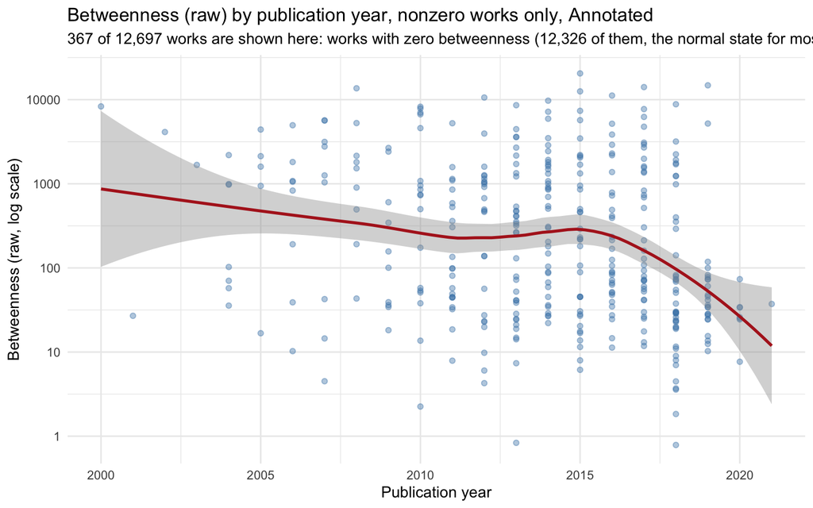

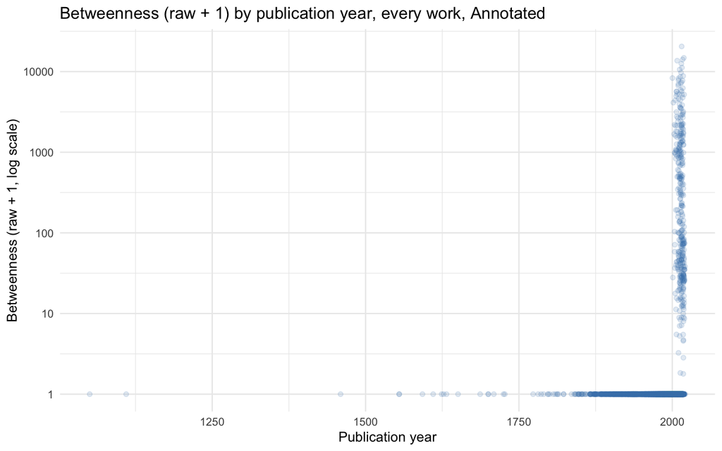

**Annotated, seed filtered**

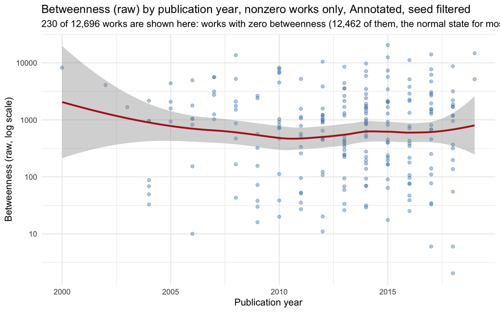

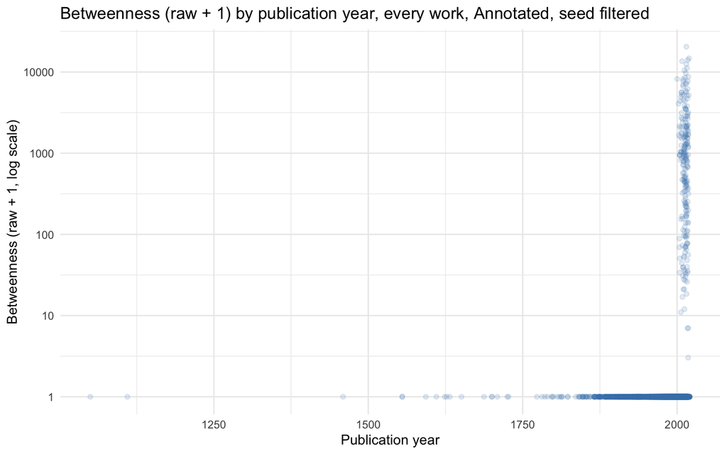

The boundary at 2000 comes from the graph and not from the history of the field. A work can have nonzero betweenness only when it both cites other works and is cited, and only the annotated papers cite anything here. The works with nonzero betweenness were published between 2000 and 2021, although 48% of all works in Annotated predate 2000. 12,327 works in Annotated and 12,327 in Annotated, seed filtered are only cited, and 0 and 0 of them have nonzero betweenness. Older works therefore score zero whatever their place in the literature, and these plots cannot compare old and recent works. Among the works that can score, the Spearman correlation between publication year and betweenness is -0.26 in Annotated and -0.01 in Annotated, seed filtered, where a negative value means earlier works have higher betweenness.

## K-core decomposition

The k-core of a graph is the maximal subgraph in which every node has at least k connections to other nodes within that subgraph. It is computed by iteratively removing nodes with degree below k until no further removal is possible. A node’s **coreness** is the highest k for which it still belongs to the k-core: a coreness of 1 means the node only survives the weakest possible core (removed as soon as k reaches 2), while a high coreness means the node stays embedded even as the graph is stripped down to only its most densely-interconnected parts.

K-core decomposition is reported here purely as a **descriptive** measure, showing which works sit in dense mutual-citation relationships versus which sit at the periphery, following Alvarez-Hamelin et al. (2005). Every work, regardless of its coreness, is still included in full in every other analysis in this document: coreness only describes a work’s position, it doesn’t filter anything out.

Coreness and in-degree measure genuinely different things, worth comparing directly: in-degree simply counts how many times a work is cited, with no regard for whether those citing works are themselves well-connected. Coreness asks a structurally deeper question, whether a work sits inside a neighborhood that is *itself* densely interconnected, not just cited often in isolation. A work could have high in-degree while sitting at low coreness, if most of its citations come from otherwise peripheral, poorly-connected works; conversely, a work with only moderate in-degree can have high coreness if it’s embedded in a tightly interlinked core. The tables below show whether these two measures broadly agree on this corpus, or diverge in informative ways.

**Annotated**

| coreness | n | mean_in_degree |
| --- | --- | --- |
| 8 | 287 | 7.98 |
| 7 | 159 | 5.95 |
| 6 | 184 | 5.43 |
| 5 | 244 | 4.63 |
| 4 | 374 | 3.84 |
| 3 | 743 | 2.98 |
| 2 | 2016 | 2.00 |
| 1 | 8690 | 1.00 |

| name | title | year | coreness | in_degree |
| --- | --- | --- | --- | --- |
| price2002 | The Viking way: religion and war in late Iron Age Scandinavia, Uppsala. Price, Neil In press: The archaeology of seiðr: circumpolar traditions in Viking pre-Christian religion | 2002 | 8 | 66 |
| svanberg2003 | Death rituals in south-east Scandinavia AD 800-1000: Decolonizing the Viking Age | 2003 | 8 | 31 |
| brink2008 | Slavery in the Viking Age | 2008 | 8 | 30 |
| skre2007 | Towns and Markets, Kings and Central Places in South-Western Scandinavia C. Ad 800-950 | 2007 | 8 | 29 |
| sindbaek2007networks | Networks and nodal points: the emergence of towns in early Viking Age Scandinavia | 2007 | 8 | 23 |
| price2008dying | Dying and the Dead | 2009 | 8 | 22 |
| zachrisson1998 | Gård, gräns och gravfält, sammanhang kring ädelmetalldepåer och runstenar från vikingatid och tidigmedeltid i uppland och gästrikland. stockholm studies in archaology 15 | 1998 | 8 | 21 |
| svanberg2003a | Decolonizing the Viking Age | 2003 | 8 | 21 |
| barrett2008what | What caused the Viking Age? | 2008 | 8 | 20 |
| hedeager2011 | Iron Age Myth and Materiality: An Archaeology of Scandinavia AD 400-1000. L and | 2011 | 8 | 20 |
| feveile2006 | ASR 1000 Ribelund II, in Det AEldste Ribe: Udgravninger på Nordsiden af Ribe Å 1984-2000, ed. C. Feveile. (Ribe Studier 1.2.) Aarhus: Jysk Arkaeologisk Selskab | 2006 | 8 | 20 |
| arbman1940 | Birka: Untersuchungen und Studien. 1. Die Gräber: Tafeln | 1940 | 8 | 19 |
| price2010passing | Passing into poetry: Viking-Age mortuary drama and the origins of Norse mythology | 2010 | 8 | 18 |
| price2011who | Who Was in Harold Bluetooth’s Army? Strontium Isotope Investigation of the Cemetery at the Viking Age Fortress at Trelleborg, Denmark | 2011 | 8 | 17 |
| andren2002 | Studier av nordisk förkristen ritual, Lund (Vägar till Midgård 2) | 2002 | 8 | 17 |
| sindbaek2005 | Ruter og rutinisering. Vikingetidens Fjernhandel i Nordeuropa, [summary in English: Routes and Routinization. Viking Age Long-Distance Trade in Northern Europe | 2005 | 8 | 17 |
| graslund1980 | Birka: Untersuchungen und Studien. iv, The Burial Customs: A Study of the Graves on Björkö. Stockholm: Almqvist & Wiksell international | 1980 | 8 | 17 |
| jorgensen2009pre | Pre-christian cult at aristocratic residences and setlement complexes in southern scandinavia in the 3 rd -10 th centuries ad | 2009 | 8 | 16 |
| sindbaek2011silver | Silver economies and social ties: Long-distance interaction, long-term investments -And why the Viking Age happened | 2011 | 8 | 16 |
| price2008 | Routledge, London. 2008b. Bodylore and the Archaeology of Embedded Religion: Dramatic License in the Funerals of the Vikings | 2008 | 8 | 16 |

**Annotated, seed filtered**

| coreness | n | mean_in_degree |
| --- | --- | --- |
| 7 | 381 | 7.21 |
| 6 | 206 | 5.18 |
| 5 | 245 | 4.58 |
| 4 | 394 | 3.71 |
| 3 | 750 | 2.98 |
| 2 | 2030 | 1.99 |
| 1 | 8690 | 1.00 |

| name | title | year | coreness | in_degree |
| --- | --- | --- | --- | --- |
| price2002 | The Viking way: religion and war in late Iron Age Scandinavia, Uppsala. Price, Neil In press: The archaeology of seiðr: circumpolar traditions in Viking pre-Christian religion | 2002 | 7 | 66 |
| svanberg2003 | Death rituals in south-east Scandinavia AD 800-1000: Decolonizing the Viking Age | 2003 | 7 | 31 |
| brink2008 | Slavery in the Viking Age | 2008 | 7 | 30 |
| skre2007 | Towns and Markets, Kings and Central Places in South-Western Scandinavia C. Ad 800-950 | 2007 | 7 | 29 |
| sindbaek2007networks | Networks and nodal points: the emergence of towns in early Viking Age Scandinavia | 2007 | 7 | 22 |
| price2008dying | Dying and the Dead | 2009 | 7 | 21 |
| zachrisson1998 | Gård, gräns och gravfält, sammanhang kring ädelmetalldepåer och runstenar från vikingatid och tidigmedeltid i uppland och gästrikland. stockholm studies in archaology 15 | 1998 | 7 | 21 |
| svanberg2003a | Decolonizing the Viking Age | 2003 | 7 | 21 |
| hedeager2011 | Iron Age Myth and Materiality: An Archaeology of Scandinavia AD 400-1000. L and | 2011 | 7 | 20 |
| feveile2006 | ASR 1000 Ribelund II, in Det AEldste Ribe: Udgravninger på Nordsiden af Ribe Å 1984-2000, ed. C. Feveile. (Ribe Studier 1.2.) Aarhus: Jysk Arkaeologisk Selskab | 2006 | 7 | 20 |
| barrett2008what | What caused the Viking Age? | 2008 | 7 | 19 |
| arbman1940 | Birka: Untersuchungen und Studien. 1. Die Gräber: Tafeln | 1940 | 7 | 19 |
| price2010passing | Passing into poetry: Viking-Age mortuary drama and the origins of Norse mythology | 2010 | 7 | 17 |
| andren2002 | Studier av nordisk förkristen ritual, Lund (Vägar till Midgård 2) | 2002 | 7 | 17 |
| sindbaek2005 | Ruter og rutinisering. Vikingetidens Fjernhandel i Nordeuropa, [summary in English: Routes and Routinization. Viking Age Long-Distance Trade in Northern Europe | 2005 | 7 | 17 |
| graslund1980 | Birka: Untersuchungen und Studien. iv, The Burial Customs: A Study of the Graves on Björkö. Stockholm: Almqvist & Wiksell international | 1980 | 7 | 17 |
| price2011who | Who Was in Harold Bluetooth’s Army? Strontium Isotope Investigation of the Cemetery at the Viking Age Fortress at Trelleborg, Denmark | 2011 | 7 | 16 |
| price2008 | Routledge, London. 2008b. Bodylore and the Archaeology of Embedded Religion: Dramatic License in the Funerals of the Vikings | 2008 | 7 | 16 |
| skre2008 | Dark Age Towns: The Kaupang Case. Reply to Przemysław Urbańczyk | 2008 | 7 | 16 |
| wamers1985 | Insularer Metallschmuck in Wikingerzeitlichen Gräbern Nordeuropas: Untersuchungen zur Skandinavischen Westexpansion. (Ofa-Bücher 56.) Neumünster | 1985 | 7 | 16 |

At the highest coreness (k = 8), Annotated holds 287 works. 5 of them are also among the five most cited and 5 among the five highest-betweenness works. In Annotated, seed filtered, the highest coreness is k = 7 with 381 works, of which 5 are among the five most cited and 5 among the five highest-betweenness works. Where in-degree, betweenness and k-core point to the same few works, that is a stronger, cross-validated signal than any one measure alone: those works are central by several different, genuinely distinct criteria at once.

## Community detection

Community detection here produces several independent descriptions of how the graph divides, not a single answer to be triangulated. Louvain (Blondel et al. 2008) and Leiden (Traag, Waltman, and Eck 2019) ask “which groups of nodes are more densely interconnected than a random graph with the same degree sequence would predict,” a notion formalized as modularity (M. E. J. Newman 2006). Girvan-Newman (Girvan and Newman 2002) asks “which edges, if removed, disconnect otherwise-separate parts of the network.” K-means asks a third, differently-grounded question again: not about graph structure at all, but about each work’s centrality profile, grouping works that occupy similar structural positions, for example highly-cited authorities vs. high-betweenness brokers vs. peripheral works.

### Louvain, Leiden and K-means

**Note**

Louvain, Leiden and K-means are computed for both graphs in `graph_metrics()` with no visible output. Their agreement across the two graphs is reported in “What the seed filter changes”. The plotting code for each is kept in the appendix, disabled; toggle `eval: true` on any of those chunks to render it.

### Girvan-Newman

#### How it works

Louvain and Leiden each partition the graph once, at one resolution, and return a single result. Girvan-Newman (Girvan and Newman 2002) instead removes edges one at a time: at each step, it identifies the edge with the highest betweenness centrality (the edge carrying the largest number of shortest paths between all pairs of nodes in the graph), removes it, and recomputes betweenness for the remaining edges before repeating. Because a shortest path between two densely connected regions of a graph usually has to cross whichever single edge joins them, that edge tends to have disproportionately high betweenness and is removed early, while edges internal to a well-connected region, which have many alternative paths around them, are removed only much later. The result is a record of the entire removal sequence, from the original, fully connected graph down to every paper standing alone: a dendrogram. The tree below is that record. Height represents the order in which components split apart, not the raw round number, since the actual rounds are spaced too unevenly to remain legible on a linear axis; left-right position carries no information and is arranged only to avoid crossing branches.

**Annotated**

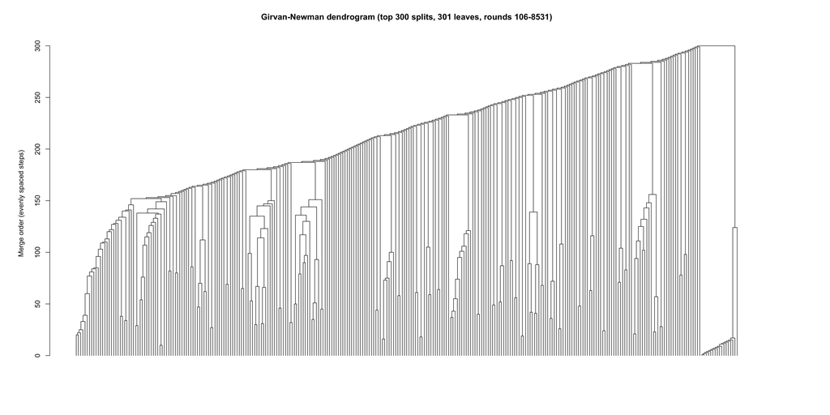

**Annotated, seed filtered**

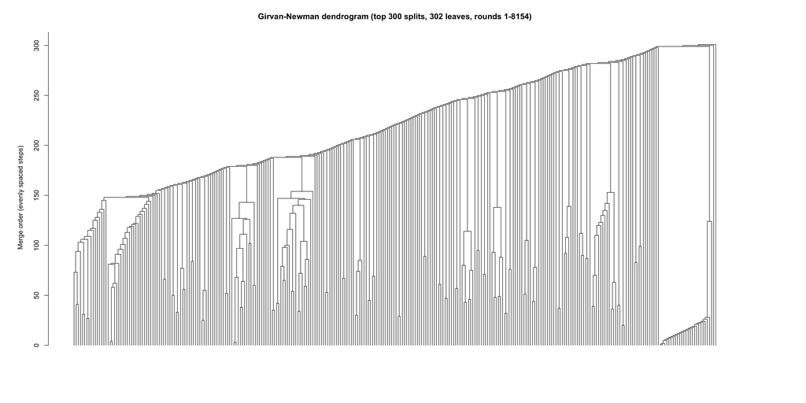

#### Choosing a stopping point

Girvan-Newman, in its original form, does not select a stopping point from this sequence (Fortunato 2010); the removal process continues until no edges remain. A refinement published two years after the original algorithm (M. E. Newman and Girvan 2004) selects the round with the highest modularity score as the working partition, and this is the conventional choice, but it fails on this corpus: modularity continues to rise as the graph fragments, reaching its maximum only once 94.2% of nodes are singleton communities (94.3% of nodes in the seed filtered run), which is not a usable partition. This is a documented limitation of modularity on sparse networks, where it can lack a clear maximum and instead admit many different high-scoring partitions (Good, de Montjoye, and Clauset 2010). The criterion used instead counts connected components directly: the point where that count starts climbing steadily, one round after another, marks where the graph is actually breaking into pieces, independent of whether modularity happens to be rising or falling at the same time. The earliest such round is 9,312 (Annotated) and 8,700 (Annotated, seed filtered), and it is used for every community grouping in the rest of this document.

**Annotated**

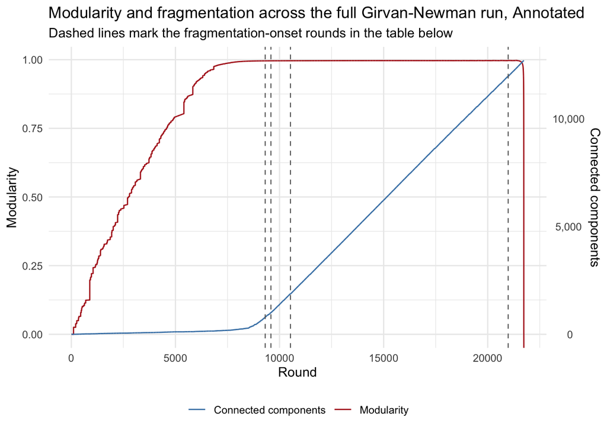

| Round | Communities | Singletons | % singleton | Largest community |
| --- | --- | --- | --- | --- |
| 9,312 | 794 | 464 | 58% | 111 |
| 9,586 | 1,000 | 664 | 66% | 111 |
| 10,525 | 1,873 | 1,528 | 82% | 104 |
| 20,983 | 11,966 | 11,608 | 97% | 6 |

**Annotated, seed filtered**

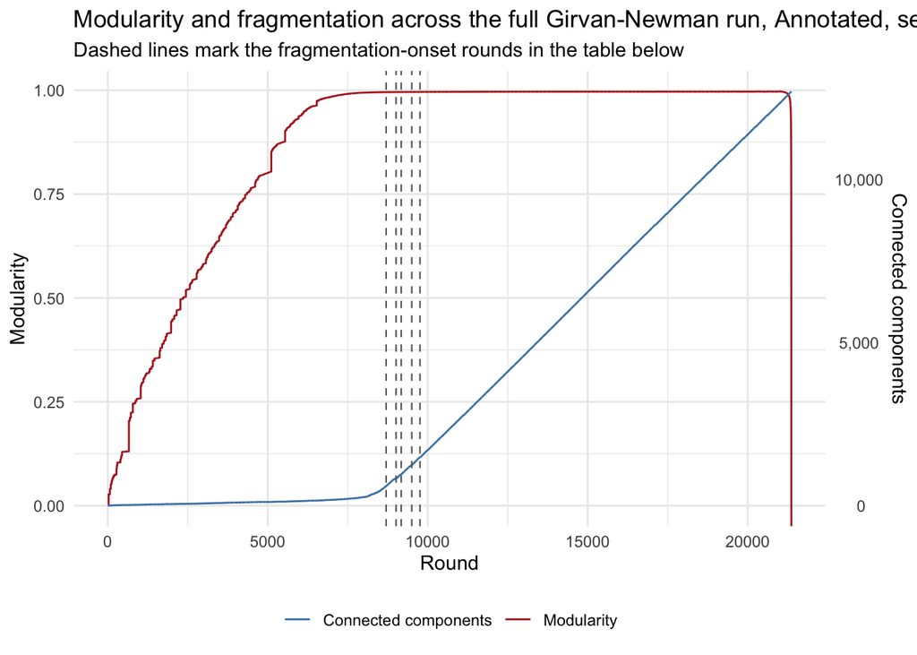

| Round | Communities | Singletons | % singleton | Largest community |
| --- | --- | --- | --- | --- |
| 8,700 | 595 | 279 | 47% | 115 |
| 9,010 | 829 | 503 | 61% | 115 |
| 9,172 | 960 | 631 | 66% | 115 |
| 9,501 | 1,247 | 909 | 73% | 115 |
| 9,758 | 1,480 | 1,140 | 77% | 109 |

#### The working partition

Only the top 20 clusters are individually coloured and the rest are grey, since beyond roughly 20 colours a reader cannot reliably distinguish them on the plot. F1 papers carry a black ring except in the tabs marked no F1 rings. Node size is each node’s betweenness centrality in that graph, so the largest dots in the dense core are the corpus’s structural bridges. The dense core is real structure and no layout parameter changes what it is. Every plot uses the Fruchterman-Reingold layout, the clearest of the layouts tried (see the appendix).

**Annotated**

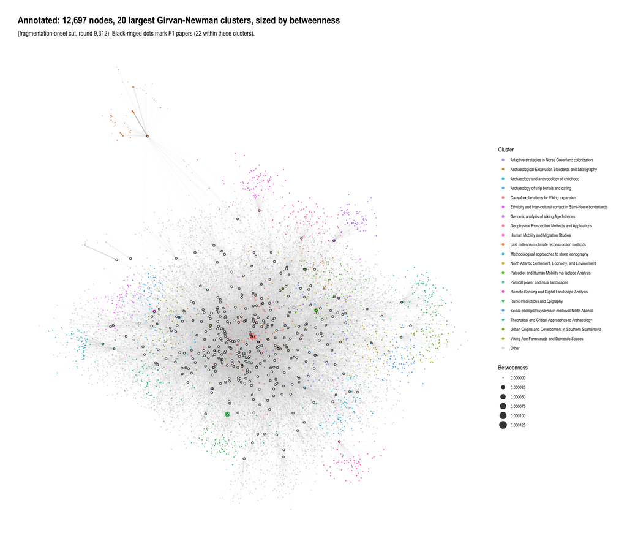

**Annotated, no F1 rings**

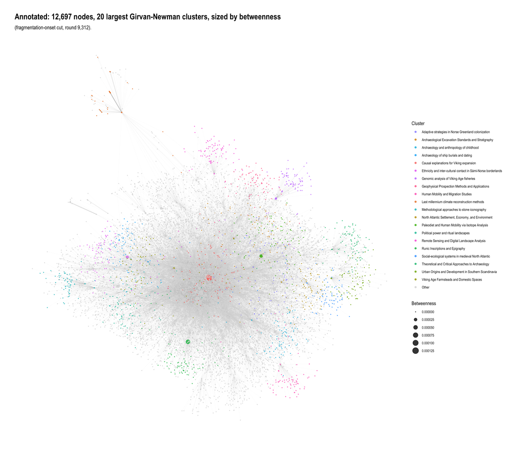

**Annotated, seed filtered**

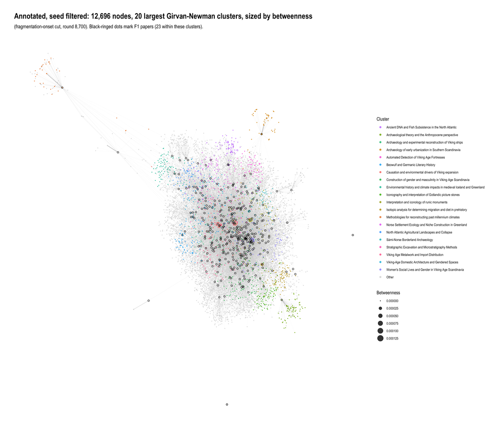

**Annotated, seed filtered, no F1 rings**

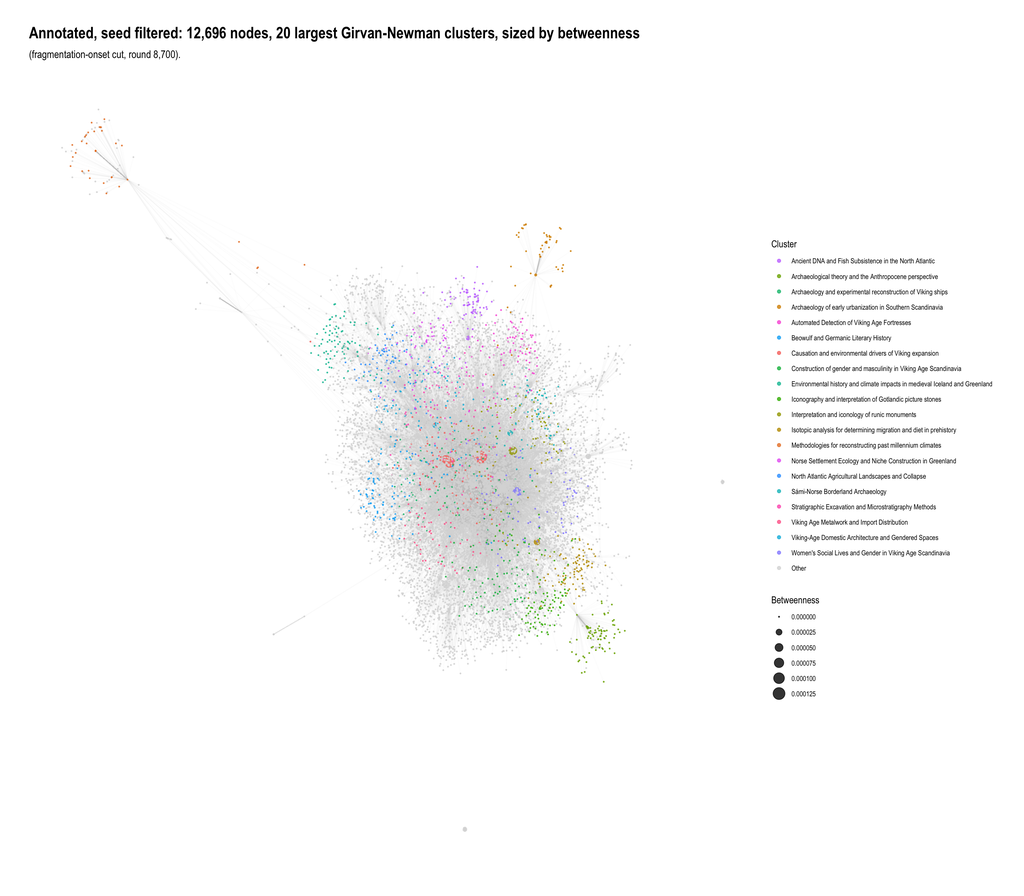

#### Community-level structure

The plots above show individual nodes coloured by community; none of them show which communities are strongly connected to which others, since edges are drawn identically whether they cross community boundaries or stay within one. This collapses each of the top 20 clusters to a single node, sized by its real membership count, with an edge between two cluster-nodes weighted by the real number of citation edges crossing between them in the original graph — the genuine inter-community structure, not individual-node detail.

**Annotated**

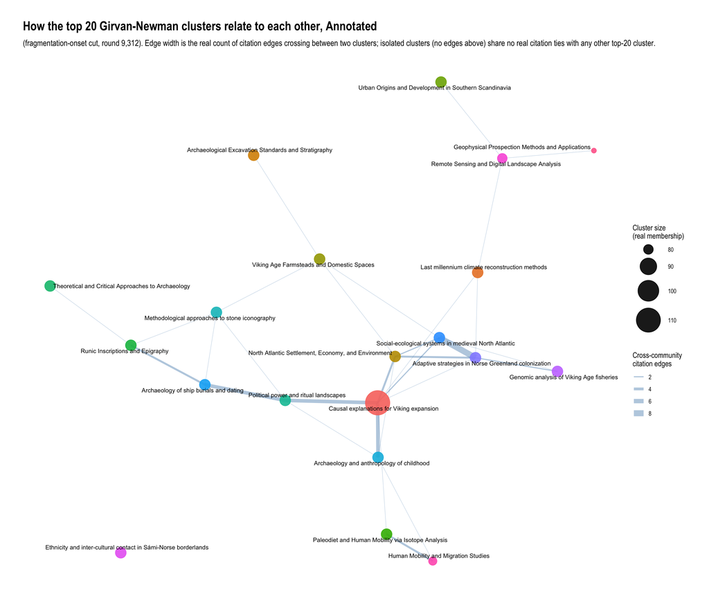

**Annotated, seed filtered**

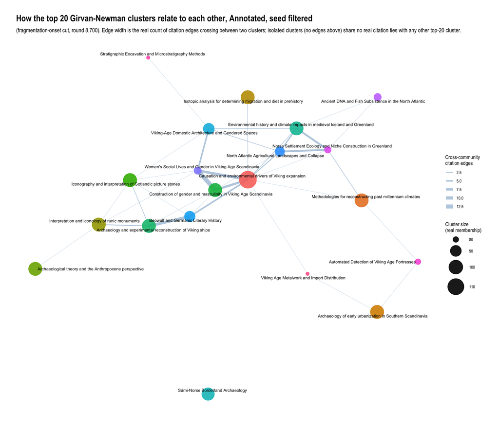

A real edge here means real papers in one cluster actually cite, or are cited by, real papers in the other; its width is that count, not an estimate. A cluster with no edges at all in this plot is real too: it means none of the top 20 clusters share a direct citation tie with it, whatever thematic similarity a reader might expect from the labels alone.

##### Relations between clusters

The graph above shows how many citations pass between clusters, and that count depends heavily on how large each cluster is. This test asks whether the citations from one cluster land in another cluster more or less often than chance would put them there, for the 20 clusters in the graph. Each citing paper keeps its whole reference list, so one paper citing many works in the same cluster is not counted as many independent events. The shuffle moves every citing paper to a randomly chosen cluster, keeps the number of citing papers in each cluster, and counts again, 1000 times. A pair is flagged when the difference holds after a Benjamini-Hochberg correction at 0.05. Each cell reads from the citing cluster in its row to the cited cluster in its column, so the matrix is not symmetric.

In Annotated, 60 citations pass between the clusters, and 92% of the 380 ordered pairs have none. After correction, 0 pairs send more citations than the shuffle and 0 send fewer. In Annotated, seed filtered, 99 citations pass between the clusters, and 88% of the 380 ordered pairs have none. After correction, 0 pairs send more citations than the shuffle and 0 send fewer.

In the heatmap, red cells are pairs where the citing cluster sends more citations to the cited cluster than the shuffle expects, blue cells send fewer, and each step on the colour scale is a doubling. Half a citation is added to each count before the ratio is taken, so that empty cells can be drawn.

**Annotated**

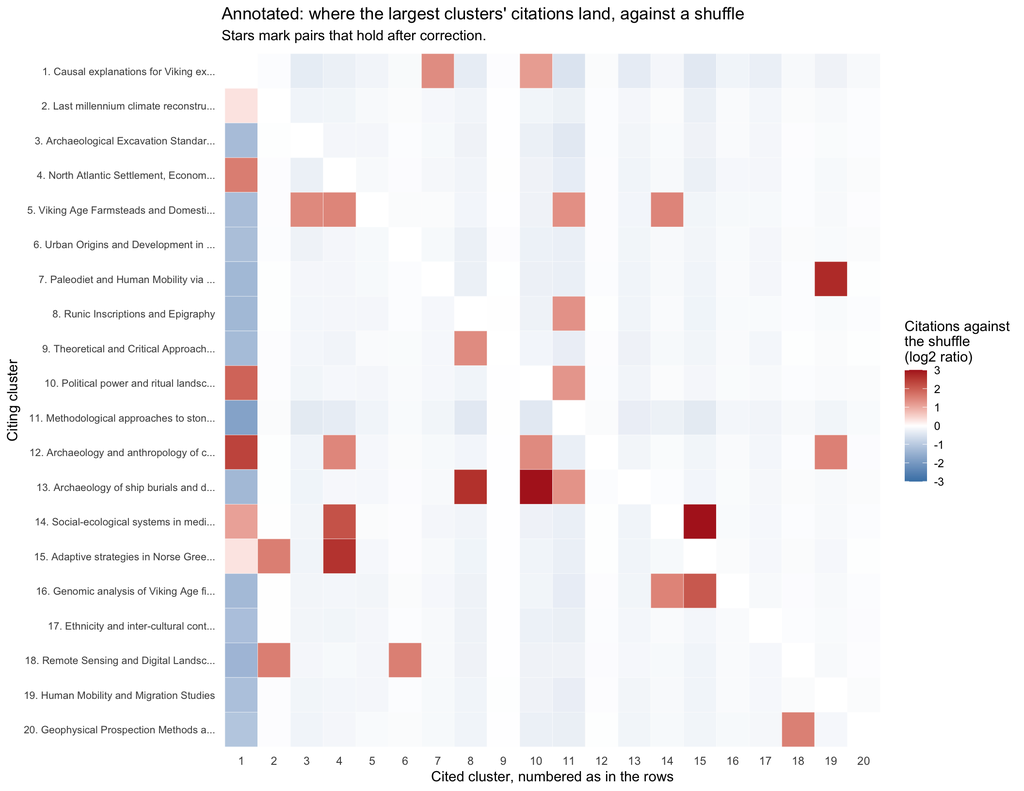

**Annotated, seed filtered**

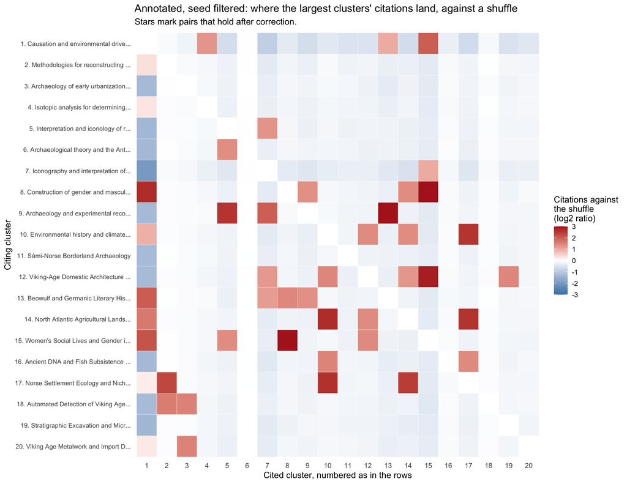

The table lists the ten pairs with the smallest p-values, whether or not they hold after correction, with the number of citing papers behind each. A pair that rests on one or two citing papers shows one paper’s bibliography and not a tendency among clusters.

**Annotated**

| Citing cluster | Cited cluster | Direction | Citations | Citing papers | Expected | p | Adjusted p |
| --- | --- | --- | --- | --- | --- | --- | --- |
| 14. Social-ecological systems in medieval… | 15. Adaptive strategies in Norse Greenlan… | More than the shuffle | 8 | 1 | 0.05 | 0.001 | 0.38 |
| 7. Paleodiet and Human Mobility via Isot… | 19. Human Mobility and Migration Studies | More than the shuffle | 3 | 1 | 0.04 | 0.004 | 0.47 |
| 13. Archaeology of ship burials and dating | 10. Political power and ritual landscapes | More than the shuffle | 5 | 1 | 0.09 | 0.005 | 0.47 |
| 13. Archaeology of ship burials and dating | 8. Runic Inscriptions and Epigraphy | More than the shuffle | 3 | 1 | 0.07 | 0.005 | 0.47 |
| 18. Remote Sensing and Digital Landscape … | 2. Last millennium climate reconstructio… | More than the shuffle | 1 | 1 | 0.01 | 0.009 | 0.51 |
| 15. Adaptive strategies in Norse Greenlan… | 4. North Atlantic Settlement, Economy, a… | More than the shuffle | 3 | 1 | 0.08 | 0.010 | 0.51 |
| 14. Social-ecological systems in medieval… | 4. North Atlantic Settlement, Economy, a… | More than the shuffle | 2 | 1 | 0.06 | 0.011 | 0.51 |
| 15. Adaptive strategies in Norse Greenlan… | 2. Last millennium climate reconstructio… | More than the shuffle | 1 | 1 | 0.01 | 0.011 | 0.51 |
| 16. Genomic analysis of Viking Age fisheries | 15. Adaptive strategies in Norse Greenlan… | More than the shuffle | 2 | 1 | 0.09 | 0.012 | 0.51 |
| 18. Remote Sensing and Digital Landscape … | 6. Urban Origins and Development in Sout… | More than the shuffle | 1 | 1 | 0.01 | 0.016 | 0.60 |

**Annotated, seed filtered**

| Citing cluster | Cited cluster | Direction | Citations | Citing papers | Expected | p | Adjusted p |
| --- | --- | --- | --- | --- | --- | --- | --- |
| 15. Women’s Social Lives and Gender in Vi… | 8. Construction of gender and masculinit… | More than the shuffle | 6 | 1 | 0.04 | 0.001 | 0.34 |
| 8. Construction of gender and masculinit… | 15. Women’s Social Lives and Gender in Vi… | More than the shuffle | 7 | 1 | 0.16 | 0.003 | 0.34 |
| 17. Norse Settlement Ecology and Niche Co… | 2. Methodologies for reconstructing past… | More than the shuffle | 2 | 1 | 0.01 | 0.004 | 0.34 |
| 9. Archaeology and experimental reconstr… | 13. Beowulf and Germanic Literary History | More than the shuffle | 8 | 1 | 0.12 | 0.006 | 0.34 |
| 18. Automated Detection of Viking Age For… | 2. Methodologies for reconstructing past… | More than the shuffle | 1 | 1 | 0.01 | 0.006 | 0.34 |
| 9. Archaeology and experimental reconstr… | 5. Interpretation and iconology of runic… | More than the shuffle | 3 | 1 | 0.09 | 0.007 | 0.34 |
| 10. Environmental history and climate imp… | 17. Norse Settlement Ecology and Niche Co… | More than the shuffle | 3 | 1 | 0.09 | 0.008 | 0.34 |
| 8. Construction of gender and masculinit… | 1. Causation and environmental drivers o… | More than the shuffle | 7 | 1 | 0.67 | 0.009 | 0.34 |
| 14. North Atlantic Agricultural Landscape… | 17. Norse Settlement Ecology and Niche Co… | More than the shuffle | 3 | 1 | 0.09 | 0.009 | 0.34 |
| 17. Norse Settlement Ecology and Niche Co… | 10. Environmental history and climate imp… | More than the shuffle | 3 | 1 | 0.07 | 0.009 | 0.34 |

#### Internal structure of individual communities

The earliest cut leaves 794 communities in Annotated and 595 in Annotated, seed filtered. A community can be taken further by replaying the removal log inside it from the cut onwards and recording each round where removing an edge divides it. Most divisions peel off one paper or a few, which is how any community comes apart and says little about its internal structure. A division counts as substantial here when its second-largest piece has at least 5 papers. The replay covers every community of 10 or more papers.

In Annotated, 21 of the 305 communities replayed have a substantial division, and the most any one has is 2. In Annotated, seed filtered, 31 of the 301 communities replayed have a substantial division, and the most any one has is 2. Every other community comes apart in pieces of fewer than 5 papers.

Each dot below is one community. The vertical axis is the largest second piece the community ever produces, so a community that only sheds single papers sits at 1. Communities above the dashed line have a substantial division and are named.

**Annotated**

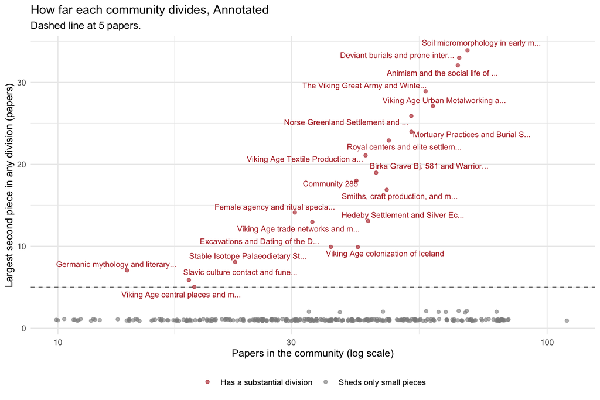

**Annotated, seed filtered**

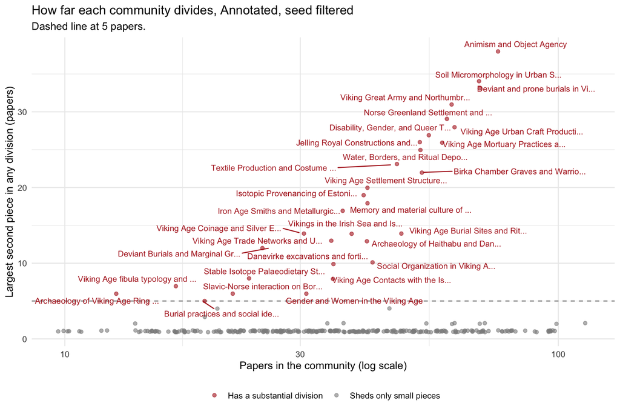

Removing one edge divides a piece into two, so a community needs two substantial divisions to have three viable pieces. With a threshold of 5 papers, 2 communities in Annotated and 2 in Annotated, seed filtered have three or more viable pieces. The table counts communities with at least one and at least two divisions when a viable piece is allowed to be smaller or required to be larger.

**Annotated**

| Smallest viable piece (papers) | Communities with a division | Communities with two or more divisions |
| --- | --- | --- |
| 2 | 31 | 4 |
| 3 | 21 | 2 |
| 5 | 21 | 2 |
| 10 | 17 | 0 |

**Annotated, seed filtered**

| Smallest viable piece (papers) | Communities with a division | Communities with two or more divisions |
| --- | --- | --- |
| 2 | 44 | 4 |
| 3 | 34 | 2 |
| 5 | 31 | 2 |
| 10 | 24 | 0 |

The next table lists the communities with a substantial division, ordered by the size of the second piece, and shows the first division of each. Each piece is named for the paper with the most citation ties inside the community that ends up in it. In Annotated, 42 of the 42 top papers are citing papers (F1), and in Annotated, seed filtered, 62 of the 62 are. Rounds after the cut is how long the community held together once the cut was made, so a small number means its two pieces were only loosely joined. Coded alike is the share of coded topics, methods and sources that the two top papers have in common, counting primary and secondary values. A low share means the division separates two subjects, and a high share means both halves are about the same subject and only their reference lists differ. In Annotated, the two top papers of a division share on average 49% of their codes (21 divisions where both are annotated), and in Annotated, seed filtered 50% of their codes (31 divisions where both are annotated). Two annotated papers picked at random share 30%. It is a rough measure, because it counts ticked boxes, so two papers on the same subject can score low when the coders ticked different categories.

**Annotated**

| Community | Papers | Substantial divisions | First division | Papers in neither | Rounds after the cut | Coded alike | Top paper, larger piece | Top paper, second piece |
| --- | --- | --- | --- | --- | --- | --- | --- | --- |
| Soil micromorphology in early medieval urban research | 69 | 1 | 35 and 34 | 0 | 164 | 20% | A Soil Micromorphological Study on the Origins of th… (2013) | Soil Micromorphology in Urban Research: Early Mediev… (2016) |
| Deviant burials and prone interments | 66 | 1 | 33 and 33 | 0 | 125 | 56% | Deconstructing the deviant burials -Kopparsvik and t… (2018) | “Deviant Burials” Und Bestattungen in Bauchlage Als … (2017) |
| Animism and the social life of things | 65 | 1 | 33 and 32 | 0 | 8 | 36% | Living places or animated objects? sámi sacrificial … (2015) | Connectedness with Things. Animated objects of Vikin… (2017) |
| The Viking Great Army and Winter Camps | 58 | 1 | 29 and 29 | 0 | 197 | 65% | In search of the Viking Great Army: Beyond the winte… (2018) | The Winter Camp of the Viking Great Army, AD 872–3, … (2016) |
| Viking Age Urban Metalworking and Craft Production | 58 | 1 | 31 and 27 | 0 | 278 | 65% | Urban craftspeople at Viking-age Kaupang () | Viking-Period Non-Ferrous Metalworking and Urban Com… (2017) |
| Norse Greenland Settlement and Economy | 53 | 1 | 27 and 26 | 0 | 409 | 58% | Norse Greenland Settlement: Reflections on Climate C… (2007) | Cultural Adaptation, Compounding Vulnerabilities and… (2012) |
| Mortuary Practices and Burial Sites | 52 | 1 | 28 and 24 | 0 | 1,215 | 91% | Passing into poetry: Viking-Age mortuary drama and t… (2010) | Dying and the Dead (2009) |
| Royal centers and elite settlements in Denmark | 48 | 1 | 25 and 23 | 0 | 624 | 53% | The Late Viking-Age Royal Constructions at Jelling, … (2013) | A palisade fit for a King: Ideal architecture in Kin… (2014) |
| Viking Age Textile Production and Costume | 43 | 1 | 22 and 21 | 0 | 337 | 20% | Tools and textiles: Production and organization in B… (2011) | Man or Woman? Perception of Gender Through Costume (2013) |
| Birka Grave Bj. 581 and Warrior Women | 44 | 1 | 25 and 19 | 0 | 884 | 56% | Viking Warrior Women? Reassessing Birka Chamber Grav… (2019) | Död amazon på Birka? -en debatt (2019) |
| Community 285 | 42 | 1 | 24 and 18 | 0 | 2,152 | 39% | Aska och Rök: Om minne och materiell kultur i nordis… (2008) | Memory and Material Culture -the rune stone at Rök (2007) |
| Smiths, craft production, and metalworking | 47 | 1 | 30 and 17 | 0 | 109 | 59% | Vikingetidens værktøjskister i landskab og mytologi (2006) | Den Ideelle og den reelle smed () |
| Female agency and ritual specialists in burial contexts | 31 | 2 | 17 and 14 | 0 | 1,224 | 62% | A Völva’s Grave at Roskilde, Denmark (2018) | Spydkvinden og den myrdede. gerdrupgraven 35 år efter (2016) |
| Hedeby Settlement and Silver Economy | 42 | 1 | 29 and 13 | 0 | 875 | 43% | Detektoruntersuchungen in haithabu 2003-2015: aussag… (2018) | Research in Hedeby: Obligations and responsibilities (2014) |
| Viking Age colonization of Iceland | 41 | 1 | 31 and 10 | 0 | 33 | 45% | Expensive errors or rational choices: the pioneer fr… (2014) | The Peopling of Iceland (2012) |
| Excavations and Dating of the Danevirke Defensive System | 35 | 1 | 25 and 10 | 0 | 491 | 56% | The Danevirke: Preliminary Results of New Excavation… (2019) | Der einzige Weg durchs Danewerk”: Zu den Ausgrabunge… (2014) |
| Stable Isotope Palaeodietary Studies | 23 | 1 | 15 and 8 | 0 | 3,525 | 38% | Diet and Status in Birka: Analysis of Stable Isotope… (2008) | Sprouting like cockle amongst the wheat”: the St. Br… (2012) |
| Viking Age trade networks and monetary systems | 33 | 2 | 26 and 7 | 0 | 1,734 | 52% | The Inhabitants: Origins and Trading Connexions (2011) | Vestfold: A monetary perspective on the Viking Age (2014) |
| Germanic mythology and literary reception | 14 | 1 | 7 and 7 | 0 | 4,791 | 23% | A winged figure from Uppåkra (2012) | Hjälter, kungar och gudar: Receptionen av bibliska e… (2004) |
| Slavic culture contact and funerary practices on Bornholm | 19 | 1 | 13 and 6 | 0 | 5,707 | 67% | Theory of practice and archaeology of culture contac… (2007) | Slavic Bornholm: Searching for the interactions betw… (2004) |
| Viking Age central places and magnate complexes | 19 | 1 | 14 and 5 | 0 | 292 | 27% | What’s in a name? an archaeological identity crisis … (2006) | Gudme and Tissø: two magnates complexes in Denmark f… (2010) |

**Annotated, seed filtered**

| Community | Papers | Substantial divisions | First division | Papers in neither | Rounds after the cut | Coded alike | Top paper, larger piece | Top paper, second piece |
| --- | --- | --- | --- | --- | --- | --- | --- | --- |
| Animism and Object Agency | 77 | 1 | 39 and 38 | 0 | 301 | 36% | Living places or animated objects? sámi sacrificial … (2015) | Connectedness with Things. Animated objects of Vikin… (2017) |
| Soil Micromorphology in Urban Sites | 71 | 1 | 37 and 34 | 0 | 319 | 20% | A Soil Micromorphological Study on the Origins of th… (2013) | Soil Micromorphology in Urban Research: Early Mediev… (2016) |
| Deviant and prone burials in Viking Age Scandinavia | 67 | 1 | 34 and 33 | 0 | 445 | 56% | “Deviant Burials” Und Bestattungen in Bauchlage Als … (2017) | Deconstructing the deviant burials -Kopparsvik and t… (2018) |
| Viking Great Army and Northumbrian Settlement Archaeology | 62 | 1 | 31 and 31 | 0 | 165 | 55% | The scale and impact of Viking settlement in Northum… (2018) | In search of the Viking Great Army: Beyond the winte… (2018) |
| Norse Greenland Settlement and Paleoeconomy | 58 | 1 | 29 and 29 | 0 | 263 | 58% | Cultural Adaptation, Compounding Vulnerabilities and… (2012) | Norse Greenland Settlement: Reflections on Climate C… (2007) |
| Viking Age Urban Craft Production and Workshops | 62 | 1 | 34 and 28 | 0 | 252 | 65% | Urban craftspeople at Viking-age Kaupang () | Viking-Period Non-Ferrous Metalworking and Urban Com… (2017) |
| Disability, Gender, and Queer Theory in Norse Mythology | 55 | 1 | 28 and 27 | 0 | 1,302 | 30% | Ability and Disability: On Bodily Variations and Bod… (2012) | Negotiating Normativities: “Odin from Lejre” as Chal… (2013) |
| Viking Age Mortuary Practices and Burial Rituals | 57 | 1 | 31 and 26 | 0 | 748 | 91% | Passing into poetry: Viking-Age mortuary drama and t… (2010) | Dying and the Dead (2009) |
| Jelling Royal Constructions and Harald Bluetooth | 53 | 1 | 27 and 26 | 0 | 760 | 53% | The Late Viking-Age Royal Constructions at Jelling, … (2013) | A palisade fit for a King: Ideal architecture in Kin… (2014) |
| Water, Borders, and Ritual Depositions | 51 | 1 | 26 and 25 | 0 | 811 | 56% | At the water’s edge (2010) | Banks, Borders and Bodies of Water in a Viking Age M… (2008) |
| Textile Production and Costume Analysis | 46 | 1 | 23 and 23 | 0 | 74 | 20% | Man or Woman? Perception of Gender Through Costume (2013) | Tools and textiles: Production and organization in B… (2011) |
| Birka Chamber Graves and Warrior Identities | 53 | 1 | 31 and 22 | 0 | 477 | 56% | Viking Warrior Women? Reassessing Birka Chamber Grav… (2019) | Död amazon på Birka? -en debatt (2019) |
| Viking Age Settlement Structure and Farmsteads | 42 | 1 | 22 and 20 | 0 | 82 | 44% | Farm and village in the Viking Age (2008) | Inconcistency and Stability: Large and Small Farmste… (2010) |
| Isotopic Provenancing of Estonian Burials | 40 | 1 | 21 and 19 | 0 | 1,738 | 55% | Human Remains, Context, and Place of Origin for the … (2020) | Isotopic provenancing of the Salme ship burials in p… (2016) |
| Memory and material culture of the Rök runestone | 42 | 1 | 24 and 18 | 0 | 2,421 | 39% | Aska och Rök: Om minne och materiell kultur i nordis… (2008) | Memory and Material Culture -the rune stone at Rök (2007) |
| Iron Age Smiths and Metallurgical Craft | 37 | 1 | 20 and 17 | 0 | 531 | 25% | En grav med smedverktøy fra tidlig vikingtid på nord… (2018) | Den Ideelle og den reelle smed () |
| Viking Age Burial Sites and Rituals | 48 | 1 | 34 and 14 | 0 | 1 | 61% | Minnesmakarnas verkstad: om vikingatida bruk av äldr… (2004) | Bones of the Earth: Imitation as Meaning in Viking A… (2005) |
| Vikings in the Irish Sea and Isle of Man | 37 | 1 | 23 and 14 | 0 | 660 | 63% | That stepping-stone in the middle of the Irish Sea’:… (2018) | Early Vikings in the Isle of Man: Old Paradigms and … (2015) |
| Viking Age Coinage and Silver Economy | 30 | 1 | 16 and 14 | 0 | 384 | 70% | Viking camps and the means of exchange in britain an… (2015) | Coins and Currency in Viking England, AD 865-954 (2014) |
| Viking Age Trade Networks and Urban Economies | 34 | 2 | 17 and 13 | 4 | 2,106 | 48% | The Inhabitants: Origins and Trading Connexions (2011) | Heimdalsjordet: Trade, Production and Communication (2017) |
| Deviant Burials and Marginal Groups | 26 | 1 | 14 and 12 | 0 | 3,961 | 73% | Death in the margin: The landscape context of Viking… (2012) | A Völva’s Grave at Roskilde, Denmark (2018) |
| Social Organization in Viking Age Colonization | 42 | 1 | 32 and 10 | 0 | 208 | 45% | Expensive errors or rational choices: the pioneer fr… (2014) | The Peopling of Iceland (2012) |
| Danevirke excavations and fortifications | 36 | 1 | 26 and 10 | 0 | 655 | 56% | The Danevirke: Preliminary Results of New Excavation… (2019) | Der einzige Weg durchs Danewerk”: Zu den Ausgrabunge… (2014) |
| Viking Age Contacts with the Islamic World | 34 | 1 | 26 and 8 | 0 | 525 | 47% | Analysis and interpretation of a unique Arabic finge… (2015) | Small Things and Wide Horizons From a Birka Perspective (2015) |
| Stable Isotope Palaeodietary Studies | 24 | 1 | 16 and 8 | 0 | 2,204 | 38% | Diet and Status in Birka: Analysis of Stable Isotope… (2008) | Sprouting like cockle amongst the wheat”: the St. Br… (2012) |
| Viking Age fibula typology and metal detector regulation | 17 | 1 | 10 and 7 | 0 | 3,168 | 20% | Korsfibler af råhedetypen: en upåagtet fibeltype fra… (2011) | Metaldetektorproblematikken – uens regler og deres k… (2015) |
| Gender and Women in the Viking Age | 30 | 1 | 24 and 6 | 0 | 2,893 | 32% | Ideas of continuity: Gender and the illusion of the … (2020) | “På mannens kärlek vilar kvinnans värde” : kvinnliga… (2009) |
| Slavic-Norse interaction on Bornholm | 22 | 1 | 16 and 6 | 0 | 4,935 | 67% | Theory of practice and archaeology of culture contac… (2007) | Slavic Bornholm: Searching for the interactions betw… (2004) |
| Archaeology of Viking Age Ring Fortresses | 13 | 1 | 7 and 6 | 0 | 2,319 | 70% | The Borgring Project 2016-2018 (2018) | New archaeological investigations at Nonnebakken, a … (2018) |
| Archaeology of Haithabu and Danevirke | 41 | 2 | 36 and 5 | 0 | 76 | 56% | Detektoruntersuchungen in haithabu 2003-2015: aussag… (2018) | Das Tor im Danewerk bei Rothenkrug: Ausgrabungen 201… (2012) |
| Burial practices and social identity in Birka | 19 | 1 | 14 and 5 | 0 | 535 | 45% | She Came from Another Place’: On the Burial of a You… (2015) | Female Viking Revisited (2018) |

Each panel draws one of those communities at the cut, split at its first substantial division. Blue is the larger piece, red is the second piece and grey is the rest of the community. A community with a second division is marked in its title, and its later pieces are inside the blue and grey.

**Annotated**

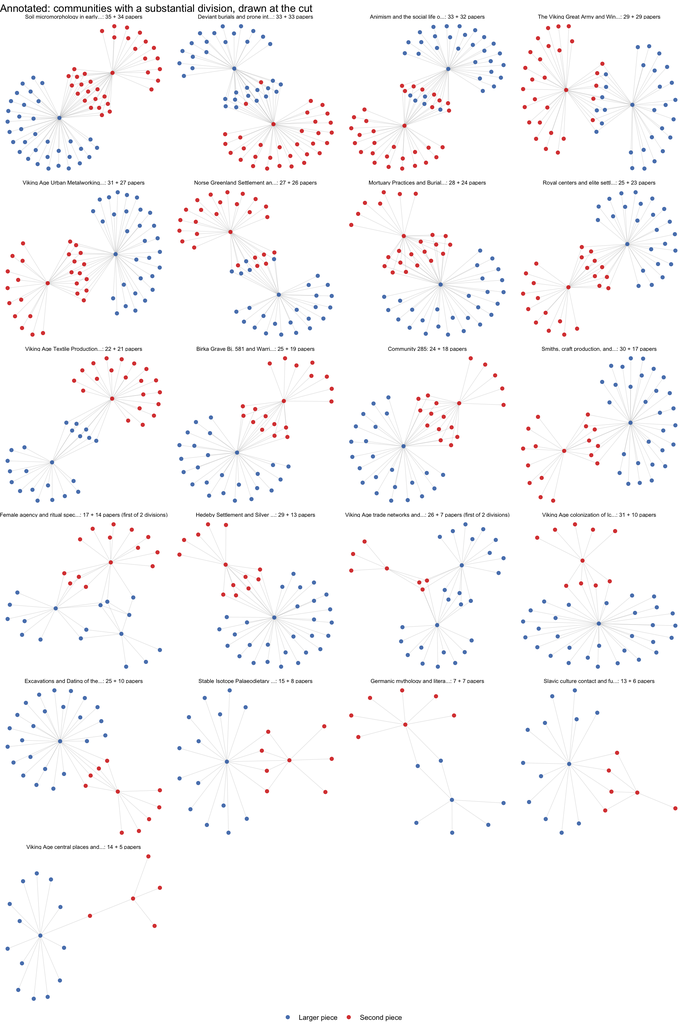

**Annotated, seed filtered**

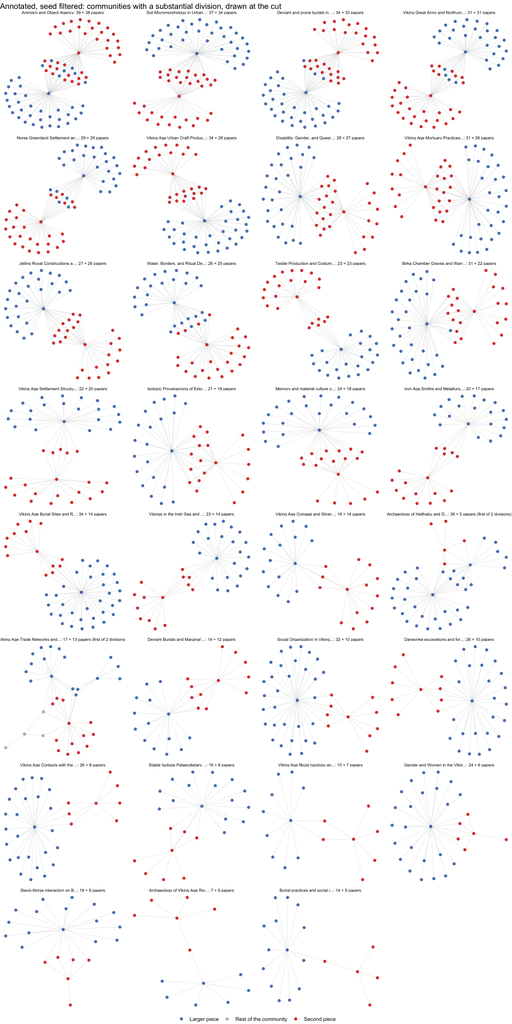

### Cluster labels

This section identifies each cluster’s most-cited papers by within-cluster citation degree, then has a language model write a label and description from their titles, independent of the F1 annotation codebook. Comparing these labels against the codebook happens separately, in `03_joined_descriptions.qmd`.

For each cluster, `select_representatives.py` ranks the cluster’s own papers by how many other members of that cluster cite them, and takes the top few as a representative sample. `label_clusters.py` sends those titles to a language model, which sorts them into named groups and writes a label and description from the largest group; a second label is written only when a real second group exists with enough titles behind it. Full detail on both steps, including the hub-independence rule and the mechanical checks run on the model’s output, is in `cluster_labelling/README.md`.

Each row is one cluster.

| Column | Meaning |
| --- | --- |
| Cluster ID | Girvan-Newman community ID at the working partition |
| Size | Cluster size |
| Shape | `Hub-dominated` (top paper’s within-cluster citation degree ≥ 5× the next-highest, `--hub-ratio-threshold` per the README), `Distributed` (otherwise), or `n/a` (no data for this cluster) |
| Label | From the language model’s primary group for this cluster |
| Description | From the language model’s primary group for this cluster |
| Secondary label | From a real second group, where one exists; blank otherwise |

**Annotated**

| Cluster ID | Size | Shape | Label | Description | Secondary label |
| --- | --- | --- | --- | --- | --- |
| 77 | 111 | Distributed | Causal explanations for Viking expansion | This cluster is organized around the theoretical and empirical search for what triggered the Viking Age, ranging from demographic anomalies like female infanticide to broader climatic shifts and diasp… | Regional Histories and Demographics |
| 35 | 81 | Hub-dominated | Political power and ritual landscapes | The dominant axis of this cluster is the intersection of political authority and physical space, analyzing how rulership was enacted through specific sites like the Danevirke and ceremonial buildings. | Rulership and Ceremonial Spaces |
| 40 | 81 | Distributed | Methodological approaches to stone iconography | This cluster is defined by the application of new imaging technologies and interpretative frameworks to analyze visual representations on picture stones and runestones from Gotland and Sweden. | Mythology and Literary Interpretation |
| 44 | 81 | Hub-dominated | Archaeology and anthropology of childhood | The primary axis organizes titles around the social construction of childhood, focusing on enculturation, play, and the quantification of age in medieval Scandinavian and English contexts. |  |
| 48 | 81 | Hub-dominated | Archaeology of ship burials and dating | This cluster is centered on the excavation and analysis of specific ship graves and burial mounds, with a strong emphasis on methodological approaches to dating these structures. |  |
| 58 | 81 | Distributed | Social-ecological systems in medieval North Atlantic | The dominant axis integrates environmental humanities, tephrochronology, and historical anthropology to understand how Norse societies in Iceland and Greenland adapted to changing landscapes and clima… | Environmental History and Human Adaptation |
| 60 | 81 | Hub-dominated | Adaptive strategies in Norse Greenland colonization | This cluster is organized around the mechanisms of adaptation and disequilibrium faced by Norse settlers in Greenland, including interactions with indigenous populations and environmental constraints. | Broader Colonial and Climatic Contexts |
| 80 | 81 | Hub-dominated | Genomic analysis of Viking Age fisheries | The primary axis focuses on the use of ancient DNA and genomic analysis to trace the origins, migration patterns, and ecological divergence of Atlantic cod during the Viking Age. | Methodological and Baseline Studies |
| 87 | 81 | Hub-dominated | Ethnicity and inter-cultural contact in Sámi-Norse borderlands | This cluster is defined by the study of ethnic identities and interactions in the border regions between Norse and Sámi populations, focusing on trade networks like the Birkarlar and archaeological ev… | Sámi-Norse Borderlands and Ethnicity |
| 113 | 81 | Distributed | Last millennium climate reconstruction methods | The dominant axis is the development and evaluation of methodologies for reconstructing past climates using proxies like tree rings, corals, and pseudoproxies to constrain future climate models. | Specific Climatic Events and Drivers |
| 118 | 81 | Hub-dominated | Archaeological Excavation Standards and Stratigraphy | This cluster is organized around the methodological frameworks of excavation, specifically focusing on single-context recording, stratigraphic interpretation, and the integration of new technologies l… |  |
| 125 | 81 | Hub-dominated | North Atlantic Settlement, Economy, and Environment | The dominant theme here is the interaction between human settlement and the harsh environments of the North Atlantic during the Viking and Medieval periods. Titles focus on subsistence strategies like… | Regional Histories and Religious Contexts |
| 205 | 81 | Hub-dominated | Urban Origins and Development in Southern Scandinavia | This cluster centers on the formation and evolution of medieval towns in Southern Scandinavia, particularly Odense and Viborg. The titles examine the transition from settlements to bishoprics, urban c… |  |
| 219 | 81 | Hub-dominated | Paleodiet and Human Mobility via Isotope Analysis | The cluster is defined by the application of stable isotope analysis (carbon, nitrogen, strontium) to reconstruct ancient human diets, weaning practices, and migration patterns. It covers both the tec… | Geological and Regional Contexts |
| 259 | 81 | Hub-dominated | Runic Inscriptions and Epigraphy | This group focuses on the study of runic inscriptions, including their translation, interpretation, and the specific work of individual rune masters. The titles explore the linguistic forms, content, … |  |
| 263 | 81 | Hub-dominated | Theoretical and Critical Approaches to Archaeology | The cluster is organized around critical reflections on the discipline of archaeology itself, including debates on materiality, identity, post-modernism, and the political implications of archaeologic… | Historical Finds and Biological Rationality |
| 121 | 80 | Hub-dominated | Remote Sensing and Digital Landscape Analysis | This cluster is defined by the use of advanced digital technologies, including LiDAR, machine learning, and remote sensing, for archaeological prospection and landscape analysis. It emphasizes automat… |  |
| 144 | 80 | Hub-dominated | Viking Age Farmsteads and Domestic Spaces | The primary axis of this cluster is the study of domestic architecture and space usage in Viking Age settlements, particularly focusing on pit houses, shielings, and gendered areas within farmsteads. … | Comparative Architecture and Settlement |
| 220 | 79 | Hub-dominated | Human Mobility and Migration Studies | This cluster is organized around the investigation of human movement in the past, utilizing methods like isotopic analysis, genomics, and modeling to distinguish between mobility and migration. It als… | Mobility Justice and Ritual Practices |
| 132 | 78 | Hub-dominated | Geophysical Prospection Methods and Applications | The cluster is dominated by titles discussing the application of geophysical techniques such as Ground-Penetrating Radar (GPR), magnetometry, and electromagnetic induction for archaeological prospecti… |  |
| 207 | 77 | Hub-dominated | Viking Age trading sites and commerce | This cluster centers on the identification and analysis of specific Viking Age trading places (kaupangs) and their role in circulation networks across Denmark and Northern Europe. The titles collectiv… | Metal hoards and detector finds |
| 241 | 76 | Hub-dominated | Archaeology of environmental change and the Anthropocene | The dominant axis here is the intersection of archaeological evidence with modern concerns about climate change, environmental degradation, and human adaptation. The cluster synthesizes case studies f… |  |
| 251 | 75 | Hub-dominated | Vendel period artefacts and material culture | This cluster is organized around the detailed typological study of specific artefact types (brooches, sword buttons) and artistic styles from the Vendel and Migration periods in Scandinavia. It includ… | Museum catalogues and specific site histories |
| 27 | 74 | Hub-dominated | Gender, family structures, and social dynamics in Viking Age Scandinavia | The primary focus is on reconstructing the social lives of women, family structures like polygyny and concubinage, and the roles of exceptional women within Viking Age Scandinavian society as depicted… | Comparative studies of violence against women and children |
| 155 | 73 | Hub-dominated | Anglo-Scandinavian metalworking and craft production | This cluster is defined by the technical and social analysis of non-ferrous metalworking, specifically focusing on strap-ends, moulds, and crucibles from Anglo-Saxon and Viking Age contexts in Britain… |  |
| 147 | 71 | Hub-dominated | Cross-cultural contact and hybridity in the Baltic region | The cluster is organized around archaeological evidence of cultural interaction, identity formation, and hybridity between Scandinavia (particularly Birka) and its eastern neighbors like Finland and E… | Cross-cultural contact and hybridity in the Baltic region |
| 170 | 71 | Hub-dominated | Geophysical survey and coastal landscape reconstruction in Norway | This cluster focuses on the application of modern geophysical techniques, particularly Airborne Lidar (ALS) and Ground Penetrating Radar (GPR), to reconstruct ancient landscapes and locate specific Vi… | Lidar and geophysical survey of coastal landscapes and burial sites |
| 59 | 69 | Hub-dominated | Chronological challenges and cultural adaptations in the prehistoric Arctic | The cluster is united by the methodological challenges of dating marine-based cultures in the Arctic, specifically addressing reservoir effects in radiocarbon calibration. It combines these technical … | Marine reservoir effects and radiocarbon dating in the Arctic |
| 124 | 69 | Distributed | Soil micromorphology in early medieval urban research | This cluster is defined by the application of soil micromorphology as a primary method to understand the formation, stratigraphy, and environmental context of early medieval trading towns. It focuses … |  |
| 206 | 69 | Hub-dominated | Object biographies and material culture theory | The cluster is organized around the theoretical framework of ‘object biographies’ and the social lives of things, exploring how artefacts (coins, heirlooms, monuments) accumulate meaning and social va… | Memory, authenticity, and biography theory |

[output cut: 296 more lines]

**Annotated, seed filtered**

| Cluster ID | Size | Shape | Label | Description | Secondary label |
| --- | --- | --- | --- | --- | --- |
| 64 | 115 | Distributed | Causation and environmental drivers of Viking expansion | This cluster is organized around the fundamental question of what triggered the Viking Age, focusing on causal theories involving climate change, human environmental impact, and social dynamics. The t… |  |
| 38 | 98 | Distributed | Iconography and interpretation of Gotlandic picture stones | The dominant axis of this cluster is the visual analysis and reinterpretation of Gotlandic picture stones, utilizing modern imaging techniques like RTI to decode their narratives. The titles focus on … | Germanic mythology and religious concepts in art |
| 42 | 98 | Hub-dominated | Construction of gender and masculinity in Viking Age Scandinavia | This cluster is primarily organized around theoretical approaches to gender, specifically examining how hegemonic masculinities were constructed through militarism and enculturation. It also criticall… | Childhood and development theories |
| 46 | 98 | Hub-dominated | Archaeology and experimental reconstruction of Viking ships | The cluster is dominated by studies focusing on the material culture of ships, including ship graves, monumental boat settings, and the use of experimental archaeology to understand these vessels. The… | Myths and literary texts |
| 56 | 98 | Distributed | Environmental history and climate impacts in medieval Iceland and Greenland | This cluster centers on the environmental conditions of medieval Scandinavia, specifically focusing on Iceland and Greenland. The titles explore the relationship between climate variability (feast and… |  |
| 110 | 98 | Distributed | Methodologies for reconstructing past millennium climates | The cluster is defined by technical papers on the science of climate reconstruction, focusing on the evaluation of proxy data, statistical methods for handling incomplete data, and the separation of n… |  |
| 200 | 98 | Hub-dominated | Archaeology of early urbanization in Southern Scandinavia | This cluster is organized around the study of early medieval urban development, with a strong focus on specific sites like Odense and Aarhus. The titles utilize material culture such as ceramics and c… |  |
| 214 | 98 | Hub-dominated | Isotopic analysis for determining migration and diet in prehistory | The cluster is driven by the application of isotopic techniques (strontium, carbon, nitrogen) to archaeological human and animal remains to reconstruct geographic origins and dietary habits. It includ… | Geological and hydrological baselines |
| 252 | 98 | Hub-dominated | Interpretation and iconology of runic monuments | This cluster focuses on the reading and analysis of rune-stones as embodied texts, examining their placement, Christianization context, and linguistic translation. The titles treat the stones as prima… | Art history and ornamentation |
| 256 | 98 | Hub-dominated | Archaeological theory and the Anthropocene perspective | The cluster is organized around theoretical reflections on the discipline of archaeology, particularly its relationship with the concept of the Anthropocene. Titles discuss emerging issues in earth sy… | Urban history and landscape evolution |
| 84 | 95 | Hub-dominated | Sámi-Norse Borderland Archaeology | This cluster organizes around the specific axis of ethnic interaction and settlement dynamics between Sámi and Norse populations in Norway’s interior and borderlands. The primary group details histori… |  |
| 33 | 89 | Hub-dominated | Beowulf and Germanic Literary History | The dominant axis here is the philological and historical analysis of early Germanic literature, specifically focusing on the dating, transmission, and contextualization of Beowulf and Widsið. The clu… | Viking-Age rulership, sites, and religious structures |
| 141 | 89 | Hub-dominated | Viking-Age Domestic Architecture and Gendered Spaces | This cluster is organized around the specific axis of domestic space, particularly the function and gendered implications of pit houses and farmstead structures in Iceland and Scandinavia. The titles … | Viking-Age burial practices and site formation |
| 122 | 86 | Hub-dominated | North Atlantic Agricultural Landscapes and Collapse | The primary axis concerns the environmental history and agricultural sustainability of the North Atlantic islands, specifically focusing on soil erosion, landscape change, and the ecological factors c… |  |
| 26 | 82 | Hub-dominated | Women’s Social Lives and Gender in Viking Age Scandinavia | This cluster is organized around the specific axis of gender dynamics, focusing on the social roles, marriage practices (polygyny/concubinage), and representation of women in both historical records a… | Women’s social lives and gender in Viking Age Scandinavia |
| 77 | 82 | Hub-dominated | Ancient DNA and Fish Subsistence in the North Atlantic | The dominant axis is the application of ancient DNA techniques to reconstruct subsistence practices, specifically focusing on the origins and movement of cod and other marine resources in Viking Age c… | Zooarchaeology and coastal settlement development |
| 58 | 81 | Hub-dominated | Norse Settlement Ecology and Niche Construction in Greenland | This cluster is organized around the specific axis of historical ecology and niche construction theory applied to Norse Greenland. It examines how environmental factors like sea ice and vegetation dyn… | Ecological theory and vegetation dynamics |
| 118 | 80 | Hub-dominated | Automated Detection of Viking Age Fortresses | The primary axis is the application of computational methods, specifically automatic landscape classification and feature detection algorithms, to identify and analyze Viking Age fortresses (ring fort… | Automated detection and landscape classification for fortresses |
| 115 | 79 | Hub-dominated | Stratigraphic Excavation and Microstratigraphy Methods | This cluster is organized around the specific axis of excavation methodology, emphasizing high-definition recording, single-context principles, and microstratigraphic analysis to understand site forma… | Urban archaeology and site formation |
| 202 | 79 | Hub-dominated | Viking Age Metalwork and Import Distribution | The dominant axis is the analysis of non-ferrous metal artifacts, focusing on the circulation of imports between Scandinavia, Anglo-Saxon England, and Ireland during the Viking Age. The cluster examin… | Specific artifact studies and catalogues |
| 215 | 79 | Hub-dominated | Mobility and Settlement Patterns | This cluster organizes around the archaeological investigation of human movement, migration, and settlement stability during the Bronze Age. The titles collectively explore theoretical frameworks for … |  |
| 129 | 78 | Hub-dominated | Geophysical Methods in Landscape Archaeology | The dominant axis here is the application of geophysical techniques like Ground-Penetrating Radar (GPR), magnetometry, and remote sensing to reconstruct past landscapes and environmental conditions. T… |  |
| 23 | 77 | Distributed | Animism and Object Agency | This cluster is defined by theoretical approaches that attribute agency, personhood, or spiritual life to material objects and places. It synthesizes archaeological case studies from Scandinavia with … |  |
| 235 | 76 | Hub-dominated | Archaeology of Environmental Change | The titles in this cluster revolve around the intersection of archaeology, environmental science, and contemporary climate change discourse. They address the concept of the Anthropocene, human resilie… |  |
| 243 | 76 | Hub-dominated | Vendel Period Burial Archaeology | This cluster focuses specifically on the Vendel period and its transition into the Viking Age, with a heavy emphasis on burial sites, grave goods (particularly brooches), and regional necropoleis in S… |  |
| 151 | 72 | Hub-dominated | Material Culture in Anglo-Saxon Britain | The cluster is organized around the study of material culture, settlement patterns, and economic networks in early medieval Britain, specifically focusing on the intersection of Anglo-Saxon and Scandi… |  |
| 121 | 71 | Distributed | Soil Micromorphology in Urban Sites | This cluster is defined by the application of soil micromorphology to understand urban development, construction materials, and living floors in medieval trading centers. The titles specifically highl… |  |
| 144 | 71 | Hub-dominated | Baltic Region Cultural Contacts | The cluster focuses on archaeological evidence of interaction, trade, and cultural hybridity between Scandinavia, Finland, and Eastern Europe during the Viking Age. Titles analyze specific artifact ty… |  |
| 165 | 71 | Hub-dominated | Lidar and Sea-Level Reconstruction | This cluster is organized around the use of advanced geospatial technologies, specifically Airborne Laser Scanning (ALS/Lidar) and geodetic analysis, to reconstruct coastal landscapes and sea-level ch… |  |
| 34 | 70 | Distributed | Female Roles in Viking Society | The cluster centers on the status, roles, and representation of women in Viking Age Scandinavia, ranging from archaeological debates about female warriors to literary analyses of gendered imagery. It … |  |

[output cut: 284 more lines]

### Communities of communities

The clusters can be grouped in turn. Two clusters are linked when papers in one cite papers in the other, and also when their citing papers cite many of the same works. A single run of one community-detection method is a weak basis for groups here, because the result changes with the method, the resolution and the definition of a link. The grouping below therefore runs 8 variants, with 5 random seeds each, on every cluster of every size. The variants are Leiden at four resolutions, Louvain, Infomap on undirected and on directed links, and Leiden on shared references. Two clusters share a group when they were grouped together in at least 50% of the runs on average. A cluster forms a group alone when no other cluster meets that test with it, which means the variants disagree about which cluster it belongs with. Each group reports the share of runs in which its members stayed together. A high share is necessary but not enough, because weakly linked clusters can be grouped together consistently without sharing a theme, so the cluster labels in each row need reading as well.

**Annotated**

794 clusters fall into 18 groups of two or more clusters, and 1 cluster stays alone. The table lists the groups of two or more clusters, and larger clusters are those with 10 or more papers. The figures show only the larger clusters. 1 group has no larger cluster and does not appear in the legend.

| Group | Clusters | Larger clusters | Papers | Agreement | Largest clusters |
| --- | --- | --- | --- | --- | --- |
| 1 | 53 | 47 | 1948 | 83% | Archaeological Excavation Standards and Stratigraphy (81); Geophysical Prospection Methods and Applications (78); Viking Age trading sites and commerce (77) |
| 2 | 63 | 42 | 1720 | 75% | Runic Inscriptions and Epigraphy (81); Object biographies and material culture theory (69); Animism and the social life of things (65) |
| 3 | 50 | 40 | 1565 | 78% | Political power and ritual landscapes (81); Remote Sensing and Digital Landscape Analysis (80); Sacred places and cultic practices (69) |
| 4 | 59 | 43 | 1468 | 86% | Causal explanations for Viking expansion (111); Anglo-Scandinavian metalworking and craft production (73); Viking identity and intercultural encounters (65) |
| 5 | 80 | 28 | 1333 | 77% | North Atlantic Settlement, Economy, and Environment (81); Viking Age Farmsteads and Domestic Spaces (81); Social-ecological systems in medieval North Atlantic (81) |
| 6 | 76 | 35 | 1303 | 66% | Archaeology and anthropology of childhood (81); Gender, family structures, and social dynamics in Viking Age Scandinavia (74); Women and gender in Viking Age society (67) |
| 7 | 59 | 28 | 1060 | 82% | Paleodiet and Human Mobility via Isotope Analysis (81); Genomic analysis of Viking Age fisheries (81); Human Mobility and Migration Studies (79) |
| 8 | 25 | 14 | 531 | 75% | Ethnicity and inter-cultural contact in Sámi-Norse borderlands (81); Agrarian technology and land use in medieval Scandinavia (51); Glacier archaeology in Norway (40) |
| 9 | 11 | 8 | 362 | 71% | Cross-cultural contact and hybridity in the Baltic region (71); Finno-Ugric and Scandinavian interregional interaction (68); Finnish and Karelian archaeological landscapes (68) |
| 10 | 8 | 6 | 309 | 84% | Places of Assembly and Legal Sites (55); Political Structures and Social Terminology (54); Boathouses and Maritime Infrastructure (53) |
| 11 | 133 | 2 | 274 | 87% | Last millennium climate reconstruction methods (81); Climate variability and environmental change (62); cluster 351 (1) |
| 12 | 64 | 4 | 234 | 84% | Methodological approaches to stone iconography (81); Viking Age picture stones and Celtic art styles (51); Digital methods for Scandinavian stone monuments (28) |
| 13 | 26 | 2 | 161 | 83% | Archaeology of ship burials and dating (81); Ship burial traditions and dendrochronology (48); Norwegian Viking ship burials and their reconstruction (9) |
| 14 | 59 | 1 | 139 | 87% | Theoretical and Critical Approaches to Archaeology (81); cluster 350 (1); cluster 484 (1) |
| 15 | 3 | 3 | 118 | 70% | Trade and centers in the Eastern Baltic (50); Eastern Baltic history and archaeology (50); Prussian-Viking Archaeological Collections and Sites (18) |
| 16 | 19 | 1 | 99 | 88% | Urban Origins and Development in Southern Scandinavia (81); cluster 335 (1); cluster 725 (1) |
| 17 | 3 | 1 | 70 | 67% | AD 536 climate event and geomythology (68); cluster 618 (1); cluster 708 (1) |
| 18 | 2 | 0 | 2 | 88% | cluster 482 (1); cluster 487 (1) |

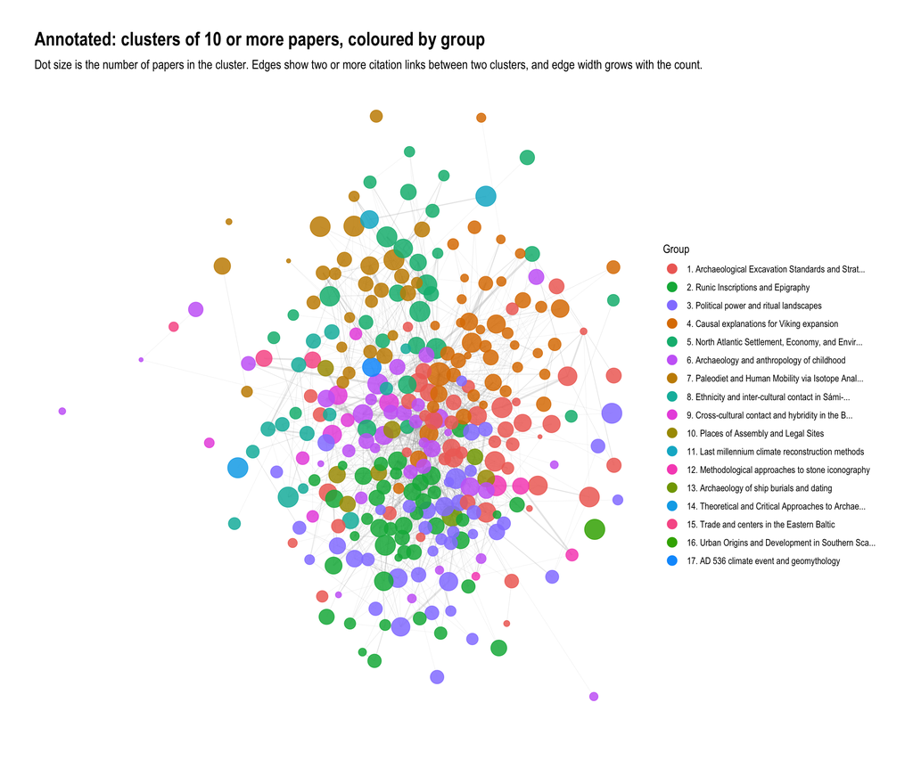

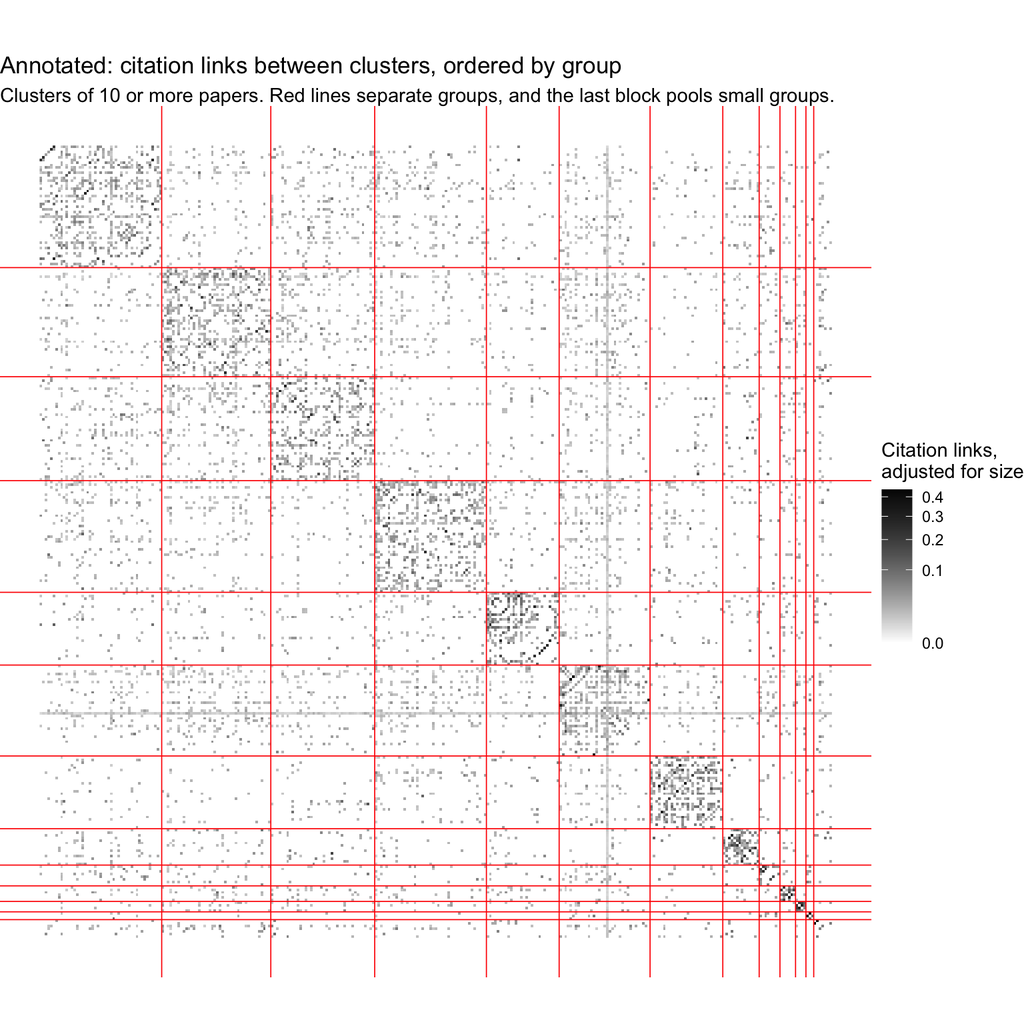

| Variant | Groups among the larger clusters | Agreement with the consensus |
| --- | --- | --- |
| Leiden, resolution 0.75 | 9 | 0.53 |
| Leiden, resolution 1 | 11 | 0.86 |
| Leiden, resolution 1.25 | 13 to 15 | 0.94 |
| Leiden, resolution 1.5 | 16 to 18 | 0.87 |
| Louvain | 10 to 12 | 0.74 |
| Infomap, undirected links | 20 to 24 | 0.18 |
| Infomap, directed links | 4 to 18 | 0.14 |
| Leiden, shared references | 8 to 9 | 0.46 |

**Annotated, seed filtered**

595 clusters fall into 13 groups of two or more clusters, and 3 clusters stay alone. The table lists the groups of two or more clusters, and larger clusters are those with 10 or more papers. The figures show only the larger clusters.

| Group | Clusters | Larger clusters | Papers | Agreement | Largest clusters |
| --- | --- | --- | --- | --- | --- |
| 1 | 52 | 48 | 2096 | 83% | Archaeology of early urbanization in Southern Scandinavia (98); Stratigraphic Excavation and Microstratigraphy Methods (79); Viking Age Metalwork and Import Distribution (79) |
| 2 | 51 | 42 | 1894 | 80% | Interpretation and iconology of runic monuments (98); Archaeology and experimental reconstruction of Viking ships (98); Animism and Object Agency (77) |
| 3 | 46 | 40 | 1545 | 81% | Beowulf and Germanic Literary History (89); Automated Detection of Viking Age Fortresses (80); Sacred places and ritual landscapes in Iron Age Sweden (69) |
| 4 | 67 | 38 | 1387 | 82% | Causation and environmental drivers of Viking expansion (115); Material Culture in Anglo-Saxon Britain (72); Viking Settlements and Material Culture in the British Isles (64) |
| 5 | 49 | 33 | 1303 | 84% | Construction of gender and masculinity in Viking Age Scandinavia (98); Women’s Social Lives and Gender in Viking Age Scandinavia (82); Female Roles in Viking Society (71) |
| 6 | 44 | 27 | 1276 | 77% | Environmental history and climate impacts in medieval Iceland and Greenland (98); Viking-Age Domestic Architecture and Gendered Spaces (90); North Atlantic Agricultural Landscapes and Collapse (86) |
| 7 | 44 | 32 | 1201 | 84% | Isotopic analysis for determining migration and diet in prehistory (98); Ancient DNA and Fish Subsistence in the North Atlantic (82); Mobility and Settlement Patterns (79) |
| 8 | 58 | 17 | 698 | 77% | Archaeological theory and the Anthropocene perspective (98); Sámi-Norse Borderland Archaeology (95); Agrarian Technology and Settlement Mounds (51) |
| 9 | 7 | 6 | 309 | 96% | Assemblies and Political Governance in Early Medieval Europe (55); Assembly Places and Royal Centers in Scandinavia (55); Boathouses and Ethnic Interaction in Arctic Norway (53) |
| 10 | 6 | 6 | 290 | 80% | Baltic Region Cultural Contacts (71); Social interaction between Baltic Finns and Svear (68); Finland’s integration into the Viking World (68) |
| 11 | 116 | 2 | 274 | 87% | Methodologies for reconstructing past millennium climates (98); Paleoclimatic Reconstructions of North Atlantic Variability (62); cluster 326 (1) |
| 12 | 49 | 5 | 261 | 84% | Iconography and interpretation of Gotlandic picture stones (98); Viking Art, Sculpture, and Runes (51); 3D analysis of Gotland picture stones (28) |
| 13 | 3 | 3 | 116 | 83% | Archaeology of Semigallia and Latvia (49); Viking Age Contacts in the Eastern Baltic (49); Wiskiauten settlement and Prussia-Sammlung archives (18) |

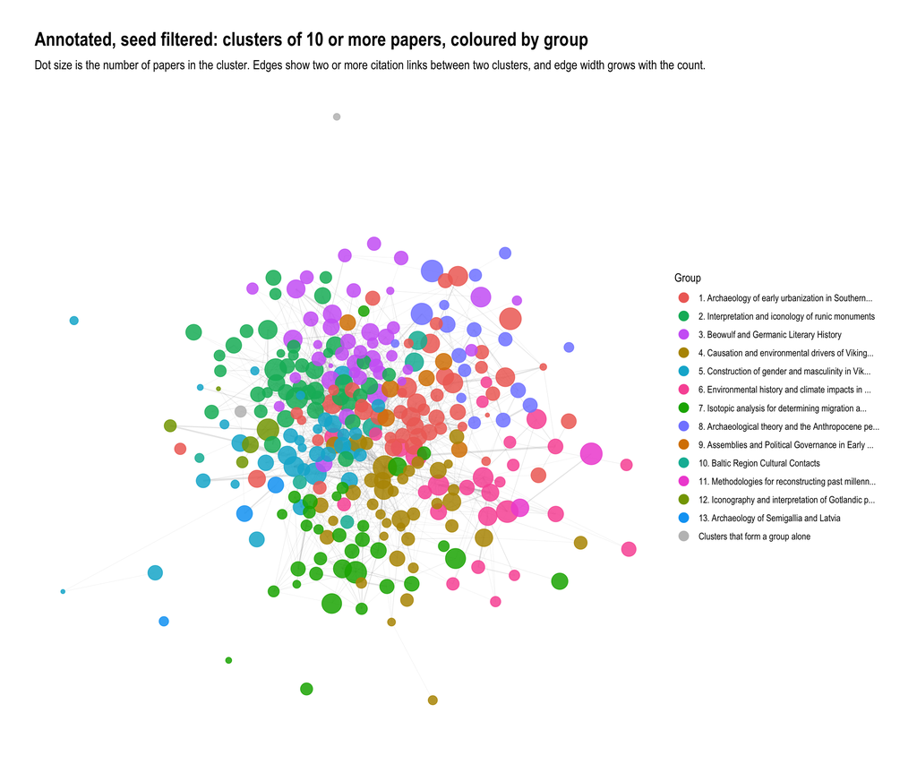

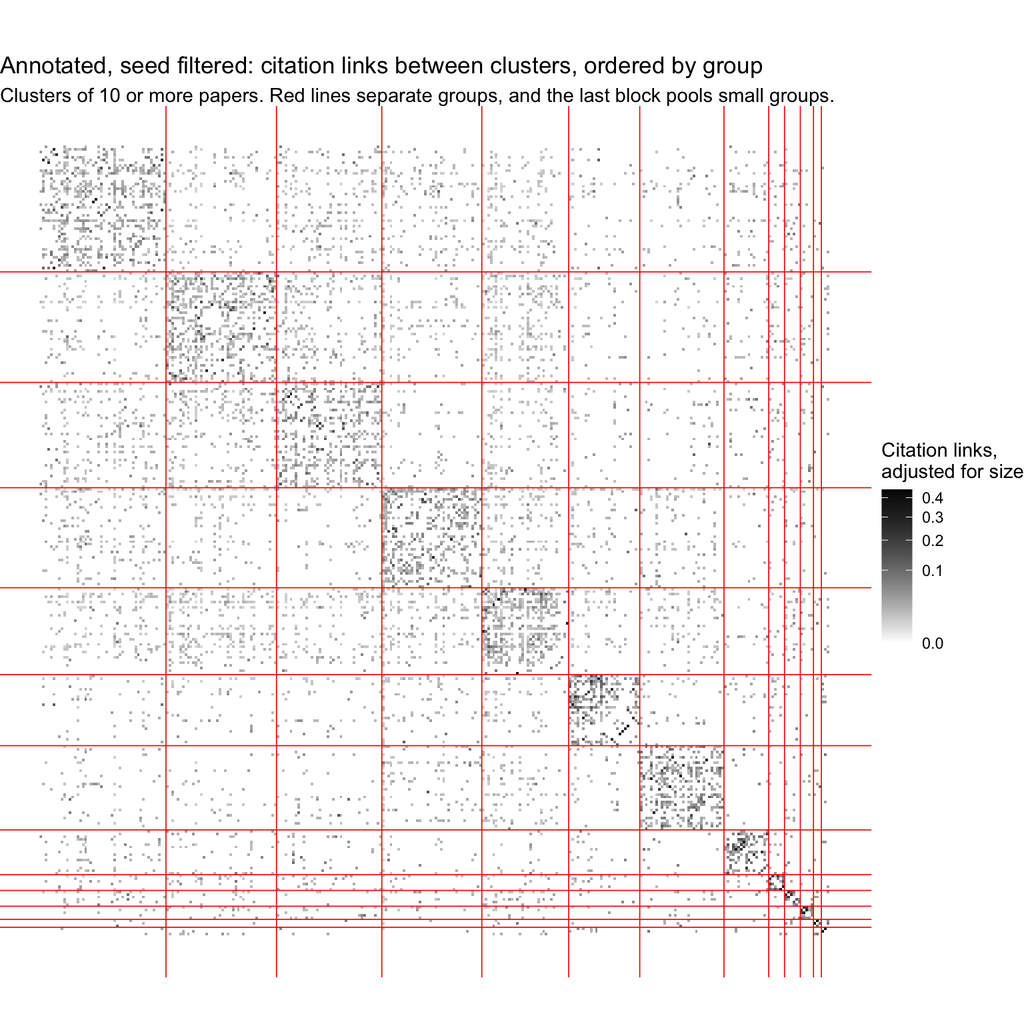

| Variant | Groups among the larger clusters | Agreement with the consensus |
| --- | --- | --- |
| Leiden, resolution 0.75 | 9 | 0.58 |
| Leiden, resolution 1 | 11 to 12 | 0.84 |
| Leiden, resolution 1.25 | 12 | 0.92 |
| Leiden, resolution 1.5 | 14 to 15 | 0.86 |
| Louvain | 10 to 12 | 0.75 |
| Infomap, undirected links | 21 to 23 | 0.40 |
| Infomap, directed links | 4 to 20 | 0.09 |
| Leiden, shared references | 8 to 9 | 0.51 |

The table before each figure lists the groups of two or more clusters, with the three largest clusters in each. In the cluster graph, each dot is a cluster sized by its papers, edges are citation links between clusters, and the legend names each group by its largest cluster, using the same numbers as the table. Grey dots are clusters that form a group alone. In the heatmap, darker cells mean more citation links between two clusters after allowing for how many links each has, and the red lines separate groups. The last table shows how closely each variant agrees with the consensus on the larger clusters, as an adjusted Rand index where 1 is identical. A variant that agrees little finds different structure or none. The consensus is built from all of them regardless, so the share reported for each group is a cautious figure.

#### Relations between groups

The groups relate to each other unevenly. For each pair of groups, the test counts the pairs of clusters, one from each group, that share at least one citation link. It compares that count with 1000 shuffles in which every cluster keeps its number of links to clusters in other groups and the partners are drawn again. Counting linked cluster pairs and not citations means one paper citing many works in another cluster counts once, and keeping each cluster’s links means groups full of heavily linked clusters do not look related to everything. A pair of groups links more or less than the shuffle when the difference holds after a Benjamini-Hochberg correction at 0.05. Only groups of two or more clusters are included.

In the heatmap, red cells are pairs of groups that link more than the shuffle expects, blue cells link less, and each step on the colour scale is a doubling. Stars mark the pairs that hold after correction. Groups are ordered so that groups with similar relations sit next to each other. Half a pair is added to each count before the ratio is taken, so that empty cells can be drawn.

**Annotated**

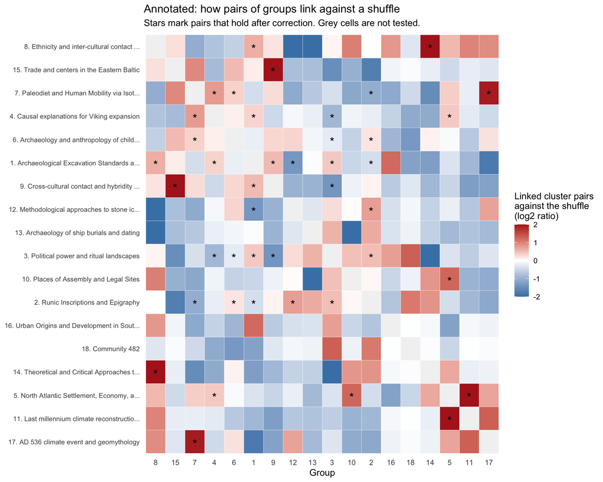

**Annotated, seed filtered**

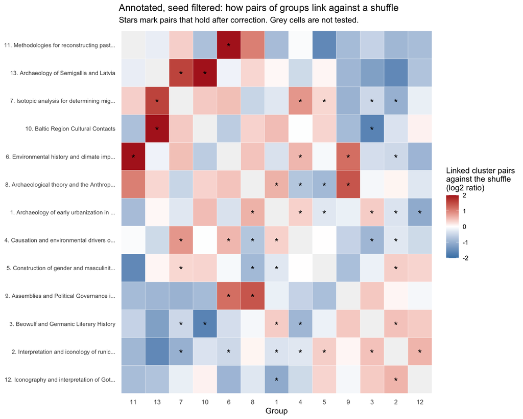

The table lists the pairs that hold after correction, strongest first. The ratio divides the observed count by the shuffle’s average.

**Annotated**

| Group A | Group B | Direction | Linked cluster pairs | Expected | Ratio | Adjusted p |
| --- | --- | --- | --- | --- | --- | --- |
| 5. North Atlantic Settlement, Economy, a… | 11. Last millennium climate reconstructio… | More than the shuffle | 10 | 1.5 | 6.83 | 0.014 |
| 3. Political power and ritual landscapes | 4. Causal explanations for Viking expansion | Less than the shuffle | 76 | 141.8 | 0.54 | 0.014 |
| 9. Cross-cultural contact and hybridity … | 15. Trade and centers in the Eastern Baltic | More than the shuffle | 6 | 0.6 | 9.45 | 0.014 |
| 2. Runic Inscriptions and Epigraphy | 3. Political power and ritual landscapes | More than the shuffle | 227 | 160.2 | 1.42 | 0.014 |
| 4. Causal explanations for Viking expansion | 7. Paleodiet and Human Mobility via Isot… | More than the shuffle | 94 | 54.2 | 1.74 | 0.014 |
| 1. Archaeological Excavation Standards a… | 3. Political power and ritual landscapes | More than the shuffle | 206 | 154.5 | 1.33 | 0.014 |
| 7. Paleodiet and Human Mobility via Isot… | 17. AD 536 climate event and geomythology | More than the shuffle | 7 | 1.5 | 4.78 | 0.014 |
| 8. Ethnicity and inter-cultural contact … | 14. Theoretical and Critical Approaches t… | More than the shuffle | 4 | 0.5 | 7.55 | 0.019 |
| 2. Runic Inscriptions and Epigraphy | 7. Paleodiet and Human Mobility via Isot… | Less than the shuffle | 30 | 62.3 | 0.48 | 0.014 |
| 5. North Atlantic Settlement, Economy, a… | 10. Places of Assembly and Legal Sites | More than the shuffle | 20 | 8.1 | 2.47 | 0.019 |
| 1. Archaeological Excavation Standards a… | 4. Causal explanations for Viking expansion | More than the shuffle | 213 | 169.3 | 1.26 | 0.014 |
| 1. Archaeological Excavation Standards a… | 2. Runic Inscriptions and Epigraphy | Less than the shuffle | 145 | 191.6 | 0.76 | 0.014 |
| 1. Archaeological Excavation Standards a… | 8. Ethnicity and inter-cultural contact … | More than the shuffle | 55 | 35.5 | 1.55 | 0.014 |
| 3. Political power and ritual landscapes | 9. Cross-cultural contact and hybridity … | Less than the shuffle | 9 | 24.2 | 0.37 | 0.019 |
| 2. Runic Inscriptions and Epigraphy | 12. Methodological approaches to stone ic… | More than the shuffle | 29 | 17.0 | 1.71 | 0.019 |
| 2. Runic Inscriptions and Epigraphy | 6. Archaeology and anthropology of child… | More than the shuffle | 268 | 233.9 | 1.15 | 0.038 |
| 4. Causal explanations for Viking expansion | 5. North Atlantic Settlement, Economy, a… | More than the shuffle | 83 | 62.6 | 1.33 | 0.025 |
| 6. Archaeology and anthropology of child… | 7. Paleodiet and Human Mobility via Isot… | More than the shuffle | 94 | 73.7 | 1.28 | 0.019 |
| 1. Archaeological Excavation Standards a… | 12. Methodological approaches to stone ic… | Less than the shuffle | 6 | 16.2 | 0.37 | 0.025 |
| 3. Political power and ritual landscapes | 6. Archaeology and anthropology of child… | Less than the shuffle | 160 | 188.4 | 0.85 | 0.038 |
| 1. Archaeological Excavation Standards a… | 9. Cross-cultural contact and hybridity … | More than the shuffle | 42 | 28.9 | 1.45 | 0.044 |

**Annotated, seed filtered**

| Group A | Group B | Direction | Linked cluster pairs | Expected | Ratio | Adjusted p |
| --- | --- | --- | --- | --- | --- | --- |
| 6. Environmental history and climate imp… | 11. Methodologies for reconstructing past… | More than the shuffle | 9 | 1.2 | 7.60 | 0.0078 |
| 3. Beowulf and Germanic Literary History | 4. Causation and environmental drivers o… | Less than the shuffle | 68 | 129.8 | 0.52 | 0.0078 |
| 4. Causation and environmental drivers o… | 7. Isotopic analysis for determining mig… | More than the shuffle | 106 | 59.4 | 1.78 | 0.0078 |
| 2. Interpretation and iconology of runic… | 3. Beowulf and Germanic Literary History | More than the shuffle | 238 | 171.6 | 1.39 | 0.0078 |
| 2. Interpretation and iconology of runic… | 5. Construction of gender and masculinit… | More than the shuffle | 270 | 208.8 | 1.29 | 0.0078 |
| 2. Interpretation and iconology of runic… | 7. Isotopic analysis for determining mig… | Less than the shuffle | 39 | 78.9 | 0.49 | 0.0078 |
| 1. Archaeology of early urbanization in … | 3. Beowulf and Germanic Literary History | More than the shuffle | 216 | 165.5 | 1.31 | 0.0078 |
| 10. Baltic Region Cultural Contacts | 13. Archaeology of Semigallia and Latvia | More than the shuffle | 3 | 0.4 | 8.52 | 0.0260 |
| 1. Archaeology of early urbanization in … | 4. Causation and environmental drivers o… | More than the shuffle | 202 | 158.9 | 1.27 | 0.0078 |
| 1. Archaeology of early urbanization in … | 2. Interpretation and iconology of runic… | Less than the shuffle | 166 | 209.1 | 0.79 | 0.0078 |
| 8. Archaeological theory and the Anthrop… | 9. Assemblies and Political Governance i… | More than the shuffle | 12 | 4.2 | 2.84 | 0.0100 |
| 6. Environmental history and climate imp… | 9. Assemblies and Political Governance i… | More than the shuffle | 17 | 7.2 | 2.36 | 0.0150 |
| 1. Archaeology of early urbanization in … | 8. Archaeological theory and the Anthrop… | More than the shuffle | 62 | 40.8 | 1.52 | 0.0100 |
| 4. Causation and environmental drivers o… | 6. Environmental history and climate imp… | More than the shuffle | 76 | 51.6 | 1.47 | 0.0100 |
| 1. Archaeology of early urbanization in … | 5. Construction of gender and masculinit… | Less than the shuffle | 165 | 201.8 | 0.82 | 0.0100 |
| 3. Beowulf and Germanic Literary History | 10. Baltic Region Cultural Contacts | Less than the shuffle | 5 | 16.8 | 0.30 | 0.0100 |
| 5. Construction of gender and masculinit… | 8. Archaeological theory and the Anthrop… | Less than the shuffle | 22 | 41.1 | 0.54 | 0.0078 |
| 7. Isotopic analysis for determining mig… | 13. Archaeology of Semigallia and Latvia | More than the shuffle | 5 | 1.4 | 3.70 | 0.0450 |
| 2. Interpretation and iconology of runic… | 4. Causation and environmental drivers o… | Less than the shuffle | 136 | 165.4 | 0.82 | 0.0180 |
| 2. Interpretation and iconology of runic… | 6. Environmental history and climate imp… | Less than the shuffle | 50 | 69.4 | 0.72 | 0.0300 |
| 1. Archaeology of early urbanization in … | 12. Iconography and interpretation of Got… | Less than the shuffle | 9 | 19.6 | 0.46 | 0.0300 |
| 3. Beowulf and Germanic Literary History | 7. Isotopic analysis for determining mig… | Less than the shuffle | 44 | 61.8 | 0.71 | 0.0340 |
| 2. Interpretation and iconology of runic… | 12. Iconography and interpretation of Got… | More than the shuffle | 31 | 20.6 | 1.51 | 0.0300 |
| 4. Causation and environmental drivers o… | 8. Archaeological theory and the Anthrop… | Less than the shuffle | 19 | 31.5 | 0.60 | 0.0340 |
| 5. Construction of gender and masculinit… | 7. Isotopic analysis for determining mig… | More than the shuffle | 94 | 76.0 | 1.24 | 0.0470 |

### Cluster shapes

This section looks inside the clusters. In most of them, one paper cites all the others. A typical cluster is a citing paper and the works it cites, with a few of those works also cited from other clusters. A cluster’s label therefore describes one paper’s bibliography more than a community of papers that cite each other, and the groups above join clusters of that kind.

A paper is a hub when it cites other members of its cluster. Each cluster of 3 or more papers falls into one of three shapes. Smaller clusters have no internal structure to describe.

#### The three shapes

**Annotated**

| Shape | What it means | Clusters | Share of clusters | Papers |
| --- | --- | --- | --- | --- |
| Single hub | One hub accounts for at least 95% of the cluster’s internal citation edges. | 296 | 90% | 10669 |
| Several hubs | Two or more hubs, and few of the works they cite are the same. | 8 | 2% | 264 |
| Shared references | Two or more hubs, and at least 20% of the works cited inside the cluster are cited by two or more of its papers. | 24 | 7% | 1296 |

**Annotated, seed filtered**

| Shape | What it means | Clusters | Share of clusters | Papers |
| --- | --- | --- | --- | --- |
| Single hub | One hub accounts for at least 95% of the cluster’s internal citation edges. | 271 | 86% | 10394 |
| Several hubs | Two or more hubs, and few of the works they cite are the same. | 21 | 7% | 708 |
| Shared references | Two or more hubs, and at least 20% of the works cited inside the cluster are cited by two or more of its papers. | 23 | 7% | 1313 |

#### What the shapes look like

Each panel is one cluster, and its title names the cluster’s shape. Red dots are hubs and blue dots are the works they cite. The panels are ordered by shape, with up to four clusters per shape. They come from clusters of 30 or more papers, spread evenly across their sizes, so they illustrate the shapes and do not sample them.

**Annotated**

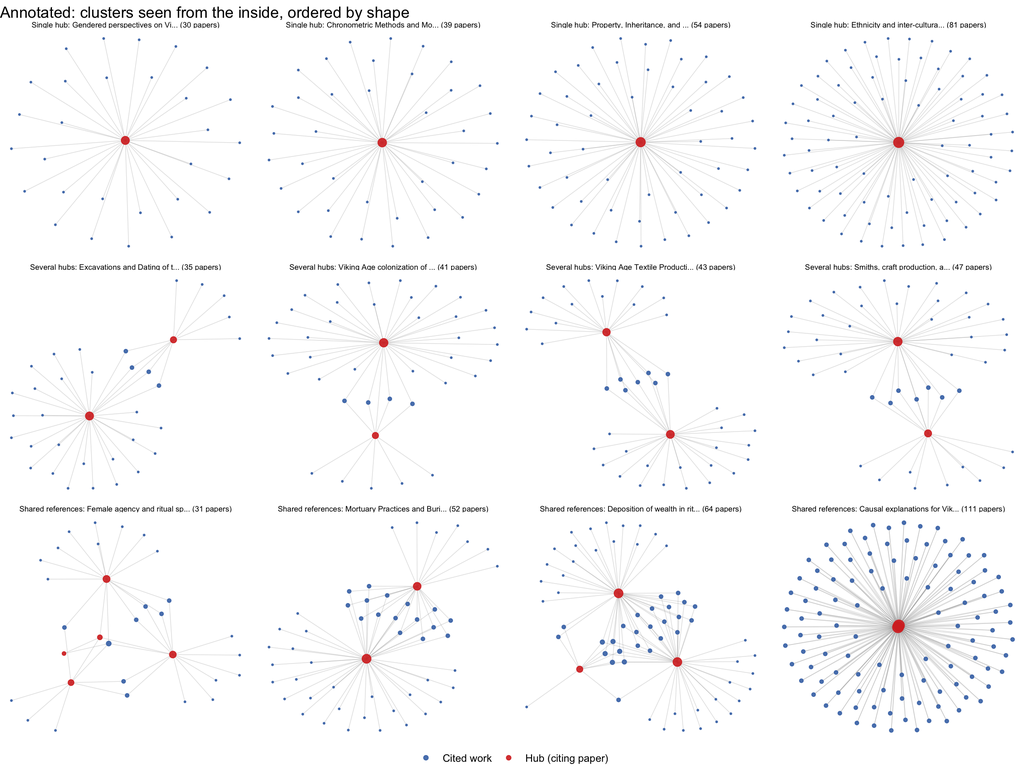

**Annotated, seed filtered**

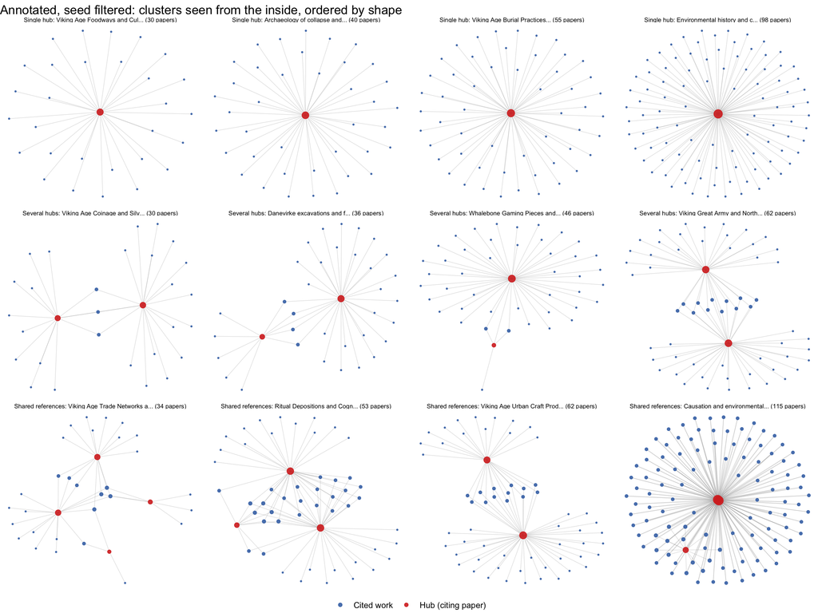

#### How much of a cluster is its own

These measures describe the edge of a cluster. The first row shows how much of a hub’s reference list the cluster keeps, and the other rows show how much of the cluster is shared with other clusters. Each row gives the median across clusters, with the first and third quartiles in brackets.

**Annotated**

| Measure | Median (quartiles) |
| --- | --- |
| Share of its hubs’ references that stay inside the cluster | 0.60 (0.47 to 0.74) |
| Share of the cluster’s cited works that other clusters also cite | 0.30 (0.21 to 0.43) |
| Share of citation edges touching the cluster that stay inside it | 0.42 (0.31 to 0.56) |
| Other clusters it shares a citation edge with | 28 (17 to 42) |

**Annotated, seed filtered**

| Measure | Median (quartiles) |
| --- | --- |
| Share of its hubs’ references that stay inside the cluster | 0.62 (0.49 to 0.74) |
| Share of the cluster’s cited works that other clusters also cite | 0.30 (0.20 to 0.41) |
| Share of citation edges touching the cluster that stay inside it | 0.44 (0.31 to 0.59) |
| Other clusters it shares a citation edge with | 28 (16 to 41) |

#### The paper behind each large cluster

The ten largest clusters, each with its hub paper and the number of that paper’s references that sit inside the cluster.

**Annotated**

| Cluster | Papers | Shape | Hub paper | Its references inside the cluster |
| --- | --- | --- | --- | --- |
| Causal explanations for Viking expansion | 111 | Shared references | Rounding up the usual suspects: Causation and the Viking Age diaspora (2010) | 110 of 170 |
| Last millennium climate reconstruction methods | 81 | Single hub | Last millennium Northern Hemisphere summer temperatures from tree r… (2017) | 80 of 225 |
| Archaeological Excavation Standards and Stratigraphy | 81 | Single hub | Single Context, Metacontext, and High Definition Archaeology: Integ… (2019) | 80 of 118 |
| North Atlantic Settlement, Economy, and Environment | 81 | Single hub | The northern frontier -North Atlantic farming during the Viking and… (2016) | 80 of 138 |
| Viking Age Farmsteads and Domestic Spaces | 81 | Single hub | The roles of pit houses and gendered spaces on Viking-Age farmstead… (2012) | 80 of 174 |
| Urban Origins and Development in Southern Scandinavia | 81 | Single hub | The Origins of Odense: New Aspects of Early Urbanisation in Souther… (2018) | 80 of 99 |
| Paleodiet and Human Mobility via Isotope Analysis | 81 | Single hub | Migration and Viking Dublin: Paleomobility and paleodiet through is… (2012) | 80 of 152 |
| Runic Inscriptions and Epigraphy | 81 | Single hub | Re-Reading Embodied Texts: An Interpretation of Rune-Stones (2000) | 80 of 126 |
| Theoretical and Critical Approaches to Archaeology | 81 | Single hub | Some reflections on heritage and archaeology in the Anthropocene (2011) | 80 of 147 |
| Political power and ritual landscapes | 81 | Single hub | Rulership and Ruler’s Sites in 1st–10th-century Scandinavia (2019) | 80 of 145 |

**Annotated, seed filtered**

| Cluster | Papers | Shape | Hub paper | Its references inside the cluster |
| --- | --- | --- | --- | --- |
| Causation and environmental drivers of Viking expansion | 115 | Shared references | Rounding up the usual suspects: Causation and the Viking Age diaspora (2010) | 113 of 170 |
| Methodologies for reconstructing past millennium climates | 98 | Single hub | Last millennium Northern Hemisphere summer temperatures from tree r… (2017) | 97 of 225 |
| Archaeology of early urbanization in Southern Scandinavia | 98 | Single hub | The Origins of Odense: New Aspects of Early Urbanisation in Souther… (2018) | 97 of 99 |
| Isotopic analysis for determining migration and diet in prehistory | 98 | Single hub | Migration and Viking Dublin: Paleomobility and paleodiet through is… (2012) | 97 of 152 |
| Interpretation and iconology of runic monuments | 98 | Single hub | Re-Reading Embodied Texts: An Interpretation of Rune-Stones (2000) | 97 of 126 |
| Archaeological theory and the Anthropocene perspective | 98 | Single hub | Some reflections on heritage and archaeology in the Anthropocene (2011) | 97 of 147 |
| Iconography and interpretation of Gotlandic picture stones | 98 | Shared references | Documenting and interpreting the picture stones of Gotland: Old pro… (2017) | 88 of 131 |
| Construction of gender and masculinity in Viking Age Scandinavia | 98 | Single hub | Playing Vikings: Militarism, hegemonic masculinities, and childhood… (2019) | 97 of 217 |
| Archaeology and experimental reconstruction of Viking ships | 98 | Single hub | The Ship Graves on Kormt – and Beyond (2019) | 97 of 171 |
| Environmental history and climate impacts in medieval Iceland and Greenland | 98 | Single hub | Medieval Iceland, Greenland, and the New Human Condition: A case st… (2017) | 97 of 151 |

#### Possible bibliography errors

Two different papers rarely cite nearly the same works. The tables list clusters whose two largest hubs share at least 70% of their references. When both records point at the same source PDF, one record is probably attached to the wrong file, and the edges from that record are suspect. Pairs like these also move their cluster into the shared references shape, so the count for that shape overstates how often independent papers cite the same works.

**Annotated**

0 clusters have two largest hubs with at least 70% of their references in common. 0 of them count as sharing references in the table of shapes.

| Result |
| --- |
| No cluster has two hubs with near-identical reference lists. |

**Annotated, seed filtered**

0 clusters have two largest hubs with at least 70% of their references in common. 0 of them count as sharing references in the table of shapes.

| Result |
| --- |
| No cluster has two hubs with near-identical reference lists. |

## What the seed filter changes

### What separates

Annotated has 1 weakly connected component(s) and Annotated, seed filtered has 3: a main body of 12,675 works and 2 smaller fragments of 12, 9 works. In Annotated those fragments join the main body only through the seed’s citations.

**NoteThe fragments**

| Fragment size | Year | Title |
| --- | --- | --- |
| 12 | 1953 | The Fragmentation of Coins in Early Medieval East Central Europeʼ |
| 12 | 1961 | ʻCoin Finds and the Problem of Money Hoarding in Early Medieval Polandʼ |
| 12 | 1987 | The Tenth Century Máramaros County (ʻHusztʼ) Dirham Hoard |
| 12 | 1994 | ʻWczesnośredniowieczny Skarb Srebrny Dzierznica II |
| 12 | 2006 | ʻSilver Handling Traditions During the Viking Age: Some Observations and Thoughts on the Phenomenon of Pecking and Bendingʼ |
| 12 | 2008 | ʻWeights and Measures in Islamʼ |
| 12 | 2009 | Najstarsze Państwo Piastów-Rezultat Przełomu czy Kontynuacji? |
| 12 | 2009 | ʻSpillings-the Largest Viking Age Silver Hoard in the Worldʼ |
| 12 | 2011 | Use of Money in the Slavic Lands from the Ninth to the Eleventh Century: the Archaeological/Numismatic Evidence |
| 12 | 2014 | Bezliudovskii Klad X v |
| 12 | 2015 | ʻWer Brachte im 10 |
| 12 | 2018 | Silver Fragmentation: Reinterpreting the Evidence of the Hoards |
| 9 | 1924 |  |
| 9 | 1930 | Article Title Not Explicitly Stated |
| 9 | 1994 |  |
| 9 | 1994 |  |
| 9 | 1996 | Традиция изгот |
| 9 | 1997 |  |
| 9 | 2012 |  |
| 9 | 2015 | Ладожские Бастионы и Горизонт В Земляного Городища (Проблема Хронологии) |
| 9 | 2018 | Stratigrafiya Zemlyanogo gorodishcha Staroy Ladogi: Itogi i perspektivy issledovaniy |

### Centrality

The comparison covers the works present in both graphs, with ghost entries excluded. A Spearman correlation near 1 and a large top-20 overlap mean the seed’s citations barely change a measure’s ranking. Betweenness is zero for most works. The seed filter takes nonzero betweenness away from 138 works that had it in Annotated and gives it to 0. The second table lists the ten works whose betweenness rank moves the most among the 231 that have nonzero betweenness in both graphs.

| Measure | Spearman correlation | Top 20 in both |
| --- | --- | --- |
| In-degree | 0.979 | 18 |
| Betweenness | 0.795 | 20 |
| PageRank | 1.000 | 20 |
| Coreness | 1.000 | 20 |

| Work | Year | Title | Rank, Annotated | Rank, seed filtered | Places gained |
| --- | --- | --- | --- | --- | --- |
| magi2011viking | 2011 | Viking Age and Early Medieval Eastern Baltic between the West and the East | 194 | 205 | -11 |
| svendsen2016how | 2016 | How did trade norms evolve in Scandinavia? Long-distance trade and social trust in the Viking Age | 197 | 207 | -10 |
| andersson2008hvorfor | 2008 | Hvorfor de første 200 årene? en introduksjon. de første 200 årene-nytt blikk på 27 skandinaviske middelalderbyer | 217 | 208 | 9 |
| wouters2016soil | 2016 | Soil Micromorphology in Urban Research: Early Medieval Antwerp (Belgium) and Viking Age Kaupang (Norway) | 214 | 222 | -8 |
| imer2014danish | 2014 | The Danish runestones: When and where? | 209 | 217 | -8 |
| lia2004vikingetidsgravenes | 2004 | Vikingetidsgravenes Rituelle Kompleksitet | 207 | 199 | 8 |
| hilberg2016hedeby | 2016 | Hedeby’s Demise in the Late Viking Age and the Shift to Schleswig | 179 | 186 | -7 |
| macphail2016microstratigraphy | 2016 | Microstratigraphy (Soil Micromorphology and Microchemistry, Soil Chemistry and Magnetic Susceptibility) | 201 | 194 | 7 |
| toplak2017deviant | 2017 | “Deviant Burials” Und Bestattungen in Bauchlage Als Teil Der Norm: Eine Fallstudie Am Beispiel Der Wikingerzeit Gotlands | 206 | 213 | -7 |
| skre2011inhabitantsactivities | 2011 | The Inhabitants: Activities | 195 | 188 | 7 |

### Communities

Partition agreement is measured on the nodes both graphs share. The adjusted Rand index and normalized mutual information both measure how much two partitions agree, from 0 for no more agreement than chance to 1 for identical groupings. Louvain and Leiden are rerun on each graph, and the Girvan-Newman partitions are the earliest fragmentation-onset cuts of the two runs. The last two rows rerun each algorithm on the Annotated graph with a different random seed. They show how much of the disagreement comes from the algorithm’s own randomness and not from the seed filter.

| Method | Adjusted Rand index | Normalized mutual information | Nodes compared |
| --- | --- | --- | --- |
| Girvan-Newman, earliest cut | 0.893 | 0.957 | 12,696 |
| Louvain | 0.636 | 0.821 | 12,696 |
| Leiden | 0.672 | 0.802 | 12,696 |
| Louvain, Annotated against its own rerun | 0.628 | 0.809 | 12,697 |
| Leiden, Annotated against its own rerun | 0.694 | 0.823 | 12,697 |

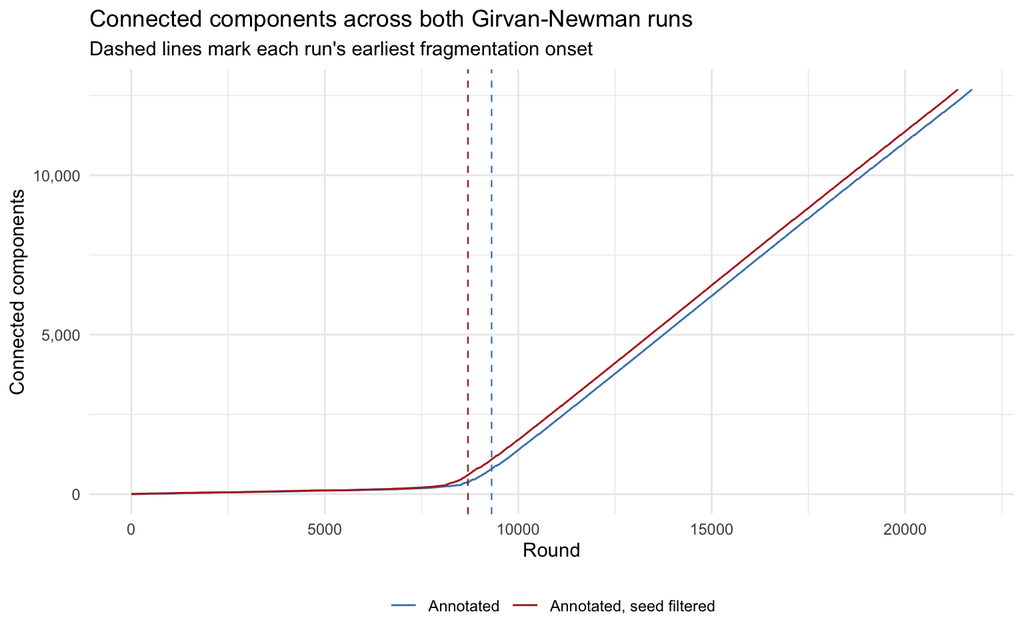

Each of the largest Annotated clusters, with the seed-filtered cluster that shares the most nodes with it. The share is the fraction of the Annotated cluster that lands in that match, and the Jaccard index is the overlap divided by the union of the two clusters.

| Cluster (Annotated) | Size | Best match (seed filtered) | Shared nodes | Share of cluster | Jaccard |
| --- | --- | --- | --- | --- | --- |
| Causal explanations for Viking expansion | 111 | Causation and environmental drivers of Viking expansion | 110 | 99% | 0.95 |
| Last millennium climate reconstruction methods | 81 | Methodologies for reconstructing past millennium climates | 81 | 100% | 0.83 |
| Archaeological Excavation Standards and Stratigraphy | 81 | Stratigraphic Excavation and Microstratigraphy Methods | 79 | 98% | 0.98 |
| North Atlantic Settlement, Economy, and Environment | 81 | North Atlantic Agricultural Landscapes and Collapse | 76 | 94% | 0.84 |
| Viking Age Farmsteads and Domestic Spaces | 81 | Viking-Age Domestic Architecture and Gendered Spaces | 80 | 99% | 0.88 |
| Urban Origins and Development in Southern Scandinavia | 81 | Archaeology of early urbanization in Southern Scandinavia | 81 | 100% | 0.83 |
| Paleodiet and Human Mobility via Isotope Analysis | 81 | Isotopic analysis for determining migration and diet in prehistory | 79 | 98% | 0.79 |
| Runic Inscriptions and Epigraphy | 81 | Interpretation and iconology of runic monuments | 80 | 99% | 0.81 |
| Theoretical and Critical Approaches to Archaeology | 81 | Archaeological theory and the Anthropocene perspective | 81 | 100% | 0.83 |
| Political power and ritual landscapes | 81 | Beowulf and Germanic Literary History | 78 | 96% | 0.85 |
| Methodological approaches to stone iconography | 81 | Iconography and interpretation of Gotlandic picture stones | 81 | 100% | 0.83 |
| Archaeology and anthropology of childhood | 81 | Construction of gender and masculinity in Viking Age Scandinavia | 81 | 100% | 0.83 |
| Archaeology of ship burials and dating | 81 | Archaeology and experimental reconstruction of Viking ships | 78 | 96% | 0.77 |
| Social-ecological systems in medieval North Atlantic | 81 | Environmental history and climate impacts in medieval Iceland and Greenland | 81 | 100% | 0.83 |
| Adaptive strategies in Norse Greenland colonization | 81 | Norse Settlement Ecology and Niche Construction in Greenland | 73 | 90% | 0.82 |
| Genomic analysis of Viking Age fisheries | 81 | Ancient DNA and Fish Subsistence in the North Atlantic | 81 | 100% | 0.99 |
| Ethnicity and inter-cultural contact in Sámi-Norse borderlands | 81 | Sámi-Norse Borderland Archaeology | 81 | 100% | 0.85 |
| Remote Sensing and Digital Landscape Analysis | 80 | Automated Detection of Viking Age Fortresses | 80 | 100% | 1.00 |
| Human Mobility and Migration Studies | 79 | Mobility and Settlement Patterns | 79 | 100% | 1.00 |
| Geophysical Prospection Methods and Applications | 78 | Geophysical Methods in Landscape Archaeology | 78 | 100% | 1.00 |

645 of the 12,696 nodes in both partitions (5.1%) sit outside the best-matching cluster of their Annotated cluster.

## Appendix: layout trials

The partition plots above use the Fruchterman-Reingold layout (`fr`, 500 iterations, with igraph’s grid speed-up). The layouts below were tried and are kept for reference with `eval: false`. Each calls the same plotting function as the main plots, so any of them can be switched on one at a time and run on either graph.

- `fr` spreads the papers that cite a hub around it, so each community reads as a region of the plot. It runs in seconds on either graph.
- `lgl` with `coolexp` lowered to 0.5, the layout used before, stretches the graph into one diagonal band and leaves the highlighted communities overlapping through its middle. It is also far slower than `fr` on the seed-filtered graph.
- `drl` stacks the papers that cite a hub on top of it, so every community collapses into a single dot and the plot shows nothing of its shape.
- `stress` (`graphlayouts::layout_with_stress()`) is faster than `drl` and built to preserve graph distance. It produced a concentric-ring pattern and was rejected.
- Untuned `lgl` places a handful of true outliers far from the rest. That is why the main plots crop the view to the 1st to 99th percentile.
- `lgl` with `repulserad` doubled spread the periphery out and left the inner core dense. `repulserad` sets the distance at which repulsion stops acting and does not change its strength, so it is the wrong lever for core density.

The Louvain, Leiden and K-means plots, also disabled. Each saves a PNG and a PDF next to this document.

## Node-table export

`analysis/bibvik_node_table.csv`, which `03_joined_descriptions.qmd` reads, holds the Annotated graph’s measures with one row per node, plus `community_gn` from the Annotated run’s earliest cut and `community_gn_seed_filtered` from the seed-filtered run. `group_gn` and `group_gn_seed_filtered` hold the consensus group of each paper’s cluster. The Girvan-Newman columns are left out when a run has not been installed.

## References

Alvarez-Hamelin, José Ignacio, Luca Dall’Asta, Alain Barrat, and Alessandro Vespignani. 2005. “Large Scale Networks Fingerprinting and Visualization Using the k-Core Decomposition.” *Advances in Neural Information Processing Systems* 18.

Blondel, Vincent D., Jean-Loup Guillaume, Renaud Lambiotte, and Etienne Lefebvre. 2008. “Fast Unfolding of Communities in Large Networks.” *Journal of Statistical Mechanics: Theory and Experiment* 2008 (10): P10008.

Fortunato, Santo. 2010. “Community Detection in Graphs.” *Physics Reports* 486 (3-5): 75–174.

Girvan, Michelle, and Mark E. J. Newman. 2002. “Community Structure in Social and Biological Networks.” *Proceedings of the National Academy of Sciences* 99 (12): 7821–26. https://doi.org/10.1073/pnas.122653799.

Good, Benjamin H., Yves-Alexandre de Montjoye, and Aaron Clauset. 2010. “The Performance of Modularity Maximization in Practical Contexts.” *Physical Review E* 81 (4): 046106.

Newman, Mark E. J. 2006. “Modularity and Community Structure in Networks.” *Proceedings of the National Academy of Sciences* 103 (23): 8577–82.

Newman, Mark EJ, and Michelle Girvan. 2004. “Finding and Evaluating Community Structure in Networks.” *Physical Review E* 69 (2): 026113. https://doi.org/10.1103/PhysRevE.69.026113.

Traag, V. A., L. Waltman, and N. J. van Eck. 2019. “From Louvain to Leiden: Guaranteeing Well-Connected Communities.” *Scientific Reports* 9:5233.

## Footnotes

[^1]: The proportion of possible edges that actually exist: edges present divided by every pair of nodes that *could* be connected. Low density is normal and expected for a citation network — most works don’t cite most other works.
[^2]: A weakly connected component treats every edge as undirected: two nodes are in the same component if a path connects them in either citation direction. This is the more forgiving of the two measures here.
[^3]: A strongly connected component requires an actual directed path in *both* directions between two nodes. Rare in citation networks, since citations are historically directed — a 2010 paper cannot cite a 2020 paper — so most strongly connected components are single isolated nodes.
[^4]: A LOESS fit, not a strict linear one, to allow for a non-constant relationship across the full year range rather than forcing a single slope.